# Introducción a los análisis estadísticos en R

Javier Marín Morales y Lucía Amalia Carrasco Ribelles

# ¿Qué es este documento?

En este archivo se puede encontrar todo el código presente en la 1ª edición de *Introducción a los análisis estadísticos en R*, de la editorial Marcombo.

Las siguientes secciones de este archivo hacen referencia a los capítulos del libro original.

# Capítulo 2. Instalación y primeros pasos en R

## Instalación

Una vez instalado R, se puede comprobar que la instalación es correcta ejecutando la siguiente línea de código, que nos imprimirá en pantalla el siguiente saludo.

```r
print("Hola mundo!")
```

```
## [1] "Hola mundo!"
```

El poner delante de las diferentes funciones de R el símbolo `?` nos permite obtener la ayuda que R dispone de la función. Puede sernos útil en muchas ocasiones.

```r
?print
```

### Instalando paquetes

#### CRAN

Es el repositorio oficial de la comunidad de R, y las librerías que alberga siguen un proceso de validación antes de quedar publicadas. Si marcamos `dependencies = TRUE` se instalarán, además, todos los paquetes que necesita la librería deseada. .

```r
install.packages("tidyverse", dependencies = TRUE)
```

#### GitHub

GitHub es un repositorio muy conocido de código en general, y también alberga librerías de R. Antes de instalar paquetes desde GitHub, se necesita instalar la librería `remotes`.

```r
install.packages("remotes", dependencies = TRUE)
remotes::install_github("tidyverse")
```

#### Bioconductor

Bioconductor ofrece *software* estadístico para análisis bioinformáticos, como la comparación de secuencias genéticas. Igualmente, antes de instalar librerías desde Bioconductor se necesita instalar la librería `Biocmanager`.

```r
    install.packages("BiocManager", dependencies = TRUE)
    BiocManager::install()
```

#### Cargar librerías

Tras la instalación, y cada vez que abramos R y necesitemos utilizar una librería, cargaremos el paquete de la siguiente manera:

```r
library(tidyverse)
```

## Importación y exportación de datos

### Utilizando comandos

La importación de archivos en R se puede realizar de manera más directa utilizando comandos. Dependiendo del tipo de archivo que queramos cargar, se utilizará una función u otra. Cada una de estas funciones, como se ha visto en el apartado anterior, tiene un conjunto de parámetros configurables que podremos consultar escribiendo `?NombreFuncion` en la consola del programa.

```r
library(readr)
dataset <- read_excel("RUTA_ARCHIVO") #Si queremos leer un archivo Excel
dataset <- read.csv("RUTA_ARCHIVO") #Si queremos leer un archivo CSV
```

En R, los símbolos `<-` equivalen al `=`.

### Datos *online*

Hay algunos conjuntos de datos, generalmente provenientes de instituciones públicas, que se pueden descargar directamente desde Internet a R. Por ejemplo, vamos a utilizar UCI, que es un repositorio de conjuntos de datos para `Machine Learning`. Se pueden encontrar en http://archive.ics.uci.edu/ml/index.php. En este caso, el carácter que separa los valores es un punto y coma, por lo que se lo indicamos.

```r
dataset <- read.csv("https://archive.ics.uci.edu/ml/machine-learning-databases/wine-quality/winequality-red.csv",
                    sep = ";")
```

Otro repositorio con un amplio catálogo de datos *online* es Kaggle [https://www.kaggle.com/datasets] (https://www.kaggle.com/datasets). Tiene conjuntos de datos de diferentes tipologías y tamaños, e incluso propone tareas y competiciones a la comunidad para resolver con ellos. Hay que registrarse para poder descargar los datos, generalmente en formato *CSV*. Se pueden cargar en R como hemos visto anteriormente.

### Datos precargados

Hay algunas librerías que incluyen conjuntos de datos, además de funciones, que se pueden cargar. Con este fin, R precarga la librería `datasets`, que contiene un gran número de conjuntos de datos de diferentes tipos. Se pueden consultar los *datasets* disponibles en la página [https://www.rdocumentation.org/packages/datasets/versions/3.6.2] (https://www.rdocumentation.org/packages/datasets/versions/3.6.2). Para cargar este tipo de conjuntos de datos almacenados en librerías, escribimos `data("NombreDataset")`. Por ejemplo, mediante el siguiente comando cargaremos un conjunto de datos del número de arrestos por asesinato, asalto y violación por cada 100.000 habitantes de los 50 estados de Estados Unidos en el año 1973. Ejecutar una carga de datos puede tardar un tiempo en llevarse a cabo, dependiendo del tamaño de los mismos.

```r
data("USArrests")
```

### Exportación

Si realizamos algún cambio en el conjunto de datos, podemos guardar una copia en el ordenador mediante los siguientes comandos. `"RUTA_ARCHIVO"` será la ruta dónde se almacene el archivo. Por ejemplo, `"./"` lo almacenará en el mismo directorio en el que está trabajando R.

```r
library(xlsx)
write.xlsx(dataset, "RUTA_ARCHIVO") #Si queremos guardar un archivo Excel
write.csv(dataset, "RUTA_ARCHIVO") #Si queremos guardar un archivo CSV
```

Al igual que las funciones de lectura, estas funciones tienen bastantes parámetros que se pueden ajustar dependiendo de cómo se quieran almacenar los datos. Para aprender más sobre ellos, se puede buscar mediante `?write.csv` o `?write.xlsx`.

# Capítulo 3. Análisis exploratorio de datos

## Primer vistazo al conjunto de datos

Procedemos a cargar el archivo de datos, que está en formato csv.

```r
insurance <- read.csv("./Data/insurance.csv")
```

Una vez cargado, podremos ver las primeras filas del conjunto de la siguiente manera:

```r
head(insurance)
```

| age | sex | bmi | children | smoker | region | charges |
| --- | --- | --- | --- | --- | --- | --- |
| 19 | female | 27.900 | 0 | yes | southwest | 16884.924 |
| 18 | male | 33.770 | 1 | no | southeast | 1725.552 |
| 28 | male | 33.000 | 3 | no | southeast | 4449.462 |
| 33 | male | 22.705 | 0 | no | northwest | 21984.471 |
| 32 | male | 28.880 | 0 | no | northwest | 3866.855 |
| 31 | female | 25.740 | 0 | no | southeast | 3756.622 |

También podremos ver con qué tipo de variable ha almacenado R cada columna del dataset:

```r
str(insurance)
```

```
## 'data.frame':    1338 obs. of  7 variables:
##  $ age     : int  19 18 28 33 32 31 46 37 37 60 ...
##  $ sex     : chr  "female" "male" "male" "male" ...
##  $ bmi     : num  27.9 33.8 33 22.7 28.9 ...
##  $ children: int  0 1 3 0 0 0 1 3 2 0 ...
##  $ smoker  : chr  "yes" "no" "no" "no" ...
##  $ region  : chr  "southwest" "southeast" "southeast" "northwest" ...
##  $ charges : num  16885 1726 4449 21984 3867 ...
```

Podemos obtener un resultado similar con la función `glimpse` de la librería `tidyverse`. Además, nos devuelve también el número de filas y columnas del conjunto de datos.

```r
glimpse(insurance)
```

```
## Rows: 1,338
## Columns: 7
## $ age      <int> 19, 18, 28, 33, 32, 31, 46, 37, 37, 60, 25, 62, 23, 56, 27, 1…
## $ sex      <chr> "female", "male", "male", "male", "male", "female", "female",…
## $ bmi      <dbl> 27.900, 33.770, 33.000, 22.705, 28.880, 25.740, 33.440, 27.74…
## $ children <int> 0, 1, 3, 0, 0, 0, 1, 3, 2, 0, 0, 0, 0, 0, 0, 1, 1, 0, 0, 0, 0…
## $ smoker   <chr> "yes", "no", "no", "no", "no", "no", "no", "no", "no", "no", …
## $ region   <chr> "southwest", "southeast", "southeast", "northwest", "northwes…
## $ charges  <dbl> 16884.924, 1725.552, 4449.462, 21984.471, 3866.855, 3756.622,…
```

Y, finalmente, podremos obtener un primera descripción estadística de las variables:

```r
summary(insurance)
```

```
##       age            sex                 bmi           children
##  Min.   :18.00   Length:1338        Min.   :15.96   Min.   :0.000
##  1st Qu.:27.00   Class :character   1st Qu.:26.30   1st Qu.:0.000
##  Median :39.00   Mode  :character   Median :30.40   Median :1.000
##  Mean   :39.21                      Mean   :30.66   Mean   :1.095
##  3rd Qu.:51.00                      3rd Qu.:34.69   3rd Qu.:2.000
##  Max.   :64.00                      Max.   :53.13   Max.   :5.000
##     smoker             region             charges
##  Length:1338        Length:1338        Min.   : 1122
##  Class :character   Class :character   1st Qu.: 4740
##  Mode  :character   Mode  :character   Median : 9382
##                                        Mean   :13270
##                                        3rd Qu.:16640
##                                        Max.   :63770
```

Si nos encargamos de codificar correctamente las variables cualitativas con el tipo `factor`, esta función también nos devolverá las frecuencias absolutas de este tipo de variables:

```r
insurance$sex = factor(insurance$sex)
insurance$smoker = factor(insurance$smoker)
insurance$region = factor(insurance$region)

summary(insurance)
```

```
##       age            sex           bmi           children     smoker
##  Min.   :18.00   female:662   Min.   :15.96   Min.   :0.000   no :1064
##  1st Qu.:27.00   male  :676   1st Qu.:26.30   1st Qu.:0.000   yes: 274
##  Median :39.00                Median :30.40   Median :1.000
##  Mean   :39.21                Mean   :30.66   Mean   :1.095
##  3rd Qu.:51.00                3rd Qu.:34.69   3rd Qu.:2.000
##  Max.   :64.00                Max.   :53.13   Max.   :5.000
##        region       charges
##  northeast:324   Min.   : 1122
##  northwest:325   1st Qu.: 4740
##  southeast:364   Median : 9382
##  southwest:325   Mean   :13270
##                  3rd Qu.:16640
##                  Max.   :63770
```

## Crear subconjuntos de datos

### Subconjuntos de variables

Una vez cargada `tidyverse`, podemos seleccionar columnas utilizando la función `select`. Por ejemplo, el siguiente código seleccionará las variables `age`, `sex` y `region`.

```r
subset <- insurance%>%select(age, sex, region)

head(subset)
```

| age | sex | region |
| --- | --- | --- |
| 19 | female | southwest |
| 18 | male | southeast |
| 28 | male | southeast |
| 33 | male | northwest |
| 32 | male | northwest |
| 31 | female | southeast |

### Subconjuntos de registros

Para seleccionar subconjuntos de filas del conjunto de datos, podemos utilizar la función `filter`. Por ejemplo, de la siguiente manera seleccionamos a las mujeres, utilizando la igualdad (`==`).

```r
subset <- insurance%>%filter(sex == "female")

head(subset)
```

| age | sex | bmi | children | smoker | region | charges |
| --- | --- | --- | --- | --- | --- | --- |
| 19 | female | 27.90 | 0 | yes | southwest | 16884.924 |
| 31 | female | 25.74 | 0 | no | southeast | 3756.622 |
| 46 | female | 33.44 | 1 | no | southeast | 8240.590 |
| 37 | female | 27.74 | 3 | no | northwest | 7281.506 |
| 60 | female | 25.84 | 0 | no | northwest | 28923.137 |
| 62 | female | 26.29 | 0 | yes | southeast | 27808.725 |

A continuación, seleccionamos a todos aquellos que no sean de la región `southwest`, utilizando la desigualdad (`!=`).

```r
subset <- insurance%>%filter(region != "southwest")

head(subset)
```

| age | sex | bmi | children | smoker | region | charges |
| --- | --- | --- | --- | --- | --- | --- |
| 18 | male | 33.770 | 1 | no | southeast | 1725.552 |
| 28 | male | 33.000 | 3 | no | southeast | 4449.462 |
| 33 | male | 22.705 | 0 | no | northwest | 21984.471 |
| 32 | male | 28.880 | 0 | no | northwest | 3866.855 |
| 31 | female | 25.740 | 0 | no | southeast | 3756.622 |
| 46 | female | 33.440 | 1 | no | southeast | 8240.590 |

A continuación, seleccionamos a los individuos entre 30 y 60 años.

```r
subset <- insurance%>%filter(age >= 30 & age <=60)

head(subset)
```

| age | sex | bmi | children | smoker | region | charges |
| --- | --- | --- | --- | --- | --- | --- |
| 33 | male | 22.705 | 0 | no | northwest | 21984.471 |
| 32 | male | 28.880 | 0 | no | northwest | 3866.855 |
| 31 | female | 25.740 | 0 | no | southeast | 3756.622 |
| 46 | female | 33.440 | 1 | no | southeast | 8240.590 |
| 37 | female | 27.740 | 3 | no | northwest | 7281.506 |
| 37 | male | 29.830 | 2 | no | northeast | 6406.411 |

Para seleccionar a los individuos que cumplan una condición u otra, utilizamos el símbolo `|`. Por ejemplo, de la siguiente manera escogeríamos a los que estén en la region `southwest` o `southeast`.

```r
subset <- insurance%>%
            filter(region == "southwest" | region == "southeast")

head(subset)
```

| age | sex | bmi | children | smoker | region | charges |
| --- | --- | --- | --- | --- | --- | --- |
| 19 | female | 27.90 | 0 | yes | southwest | 16884.924 |
| 18 | male | 33.77 | 1 | no | southeast | 1725.552 |
| 28 | male | 33.00 | 3 | no | southeast | 4449.462 |
| 31 | female | 25.74 | 0 | no | southeast | 3756.622 |
| 46 | female | 33.44 | 1 | no | southeast | 8240.590 |
| 62 | female | 26.29 | 0 | yes | southeast | 27808.725 |

Todos los filtros anteriores se pueden combinar utilizando comas. Además, para seleccionar a los individuos que cumplan una condición y otra se utiliza el símbolo `&`. Por ejemplo, de la siguiente manera seleccionaríamos a las mujeres que tengan entre 30 y 45 años y que tengan justamente 2 o 4 hijos.

```r
subset <- insurance%>%filter(sex == "female", age>=30 & age<=45, children == 2 | children == 4)

head(subset)
```

| age | sex | bmi | children | smoker | region | charges |
| --- | --- | --- | --- | --- | --- | --- |
| 31 | female | 36.630 | 2 | no | southeast | 4949.759 |
| 37 | female | 30.800 | 2 | no | southeast | 6313.759 |
| 34 | female | 37.335 | 2 | no | northwest | 5989.524 |
| 37 | female | 34.800 | 2 | yes | southwest | 39836.519 |
| 37 | female | 23.370 | 2 | no | northwest | 6686.431 |
| 32 | female | 17.765 | 2 | yes | northwest | 32734.186 |

## El concepto de frecuencia

### Tablas de frecuencia

Para obtener las frecuencias absolutas de una variable cualitativa, utilizamos la función `table`.

```r
table(insurance$region)
```

```
##
## northeast northwest southeast southwest
##       324       325       364       325
```

Hay una función más avanzada, que además nos permite obtener la frecuencia relativa y la frecuencia acumulada. Para utilizarla, necesitamos instalar la librería `epiDisplay` y cargarla. Esta función, además, genera automáticamente un gráfico descriptivo.

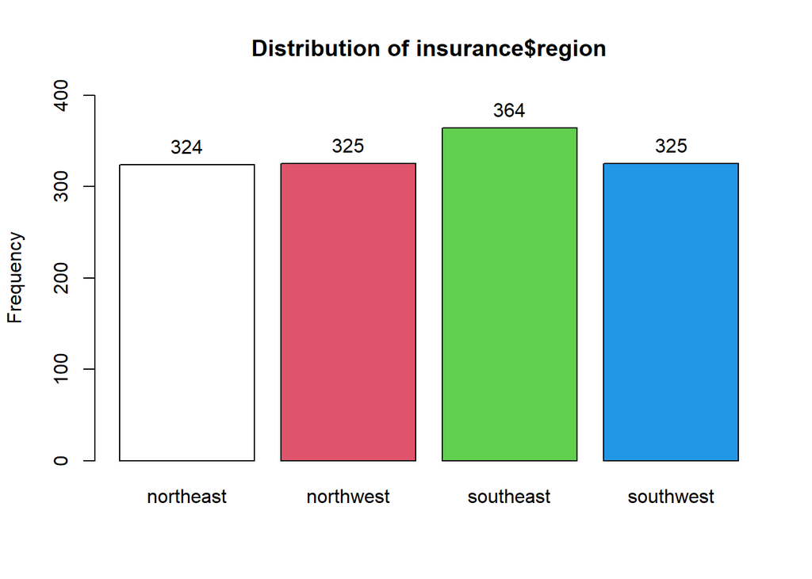

```
## insurance$region :
##           Frequency Percent Cum. percent
## northeast       324    24.2         24.2
## northwest       325    24.3         48.5
## southeast       364    27.2         75.7
## southwest       325    24.3        100.0
##   Total        1338   100.0        100.0
```

```r
library(epiDisplay)
tab1(insurance$region)
```

La forma de obtener la frecuencia relativa sin esta función, utilizando `tidyverse`, puede ser un poco más complicada de ejecutar, pero puede venir bien conocerla:

```r
insurance%>%group_by(region)%>%summarize(Frec.Absoluta = n())%>% mutate(Frec.Relativa = Frec.Absoluta/nrow(insurance))
```

| region | Frec.Absoluta | Frec.Relativa |
| --- | --- | --- |
| northeast | 324 | 0.2421525 |
| northwest | 325 | 0.2428999 |
| southeast | 364 | 0.2720478 |
| southwest | 325 | 0.2428999 |

También podemos ordenar el resultado, utilizando la función `arrange`.

```r
insurance%>%group_by(region)%>%summarize(Frec.Absoluta = n())%>%mutate(Frec.Relativa = Frec.Absoluta/nrow(insurance))%>%
arrange(desc(Frec.Relativa))
```

| region | Frec.Absoluta | Frec.Relativa |
| --- | --- | --- |
| southeast | 364 | 0.2720478 |
| northwest | 325 | 0.2428999 |
| southwest | 325 | 0.2428999 |
| northeast | 324 | 0.2421525 |

### Histogramas

La mayoría de visualizaciones del libro se han hecho utilizando la librería `ggpubr`. En los siguientes ejemplos, realiamos histogramas. Para ello, indicamos el `dataset` de referencia, y pasamos como argumento el nombre de la variable donde se almacena los datos que nos interesa.

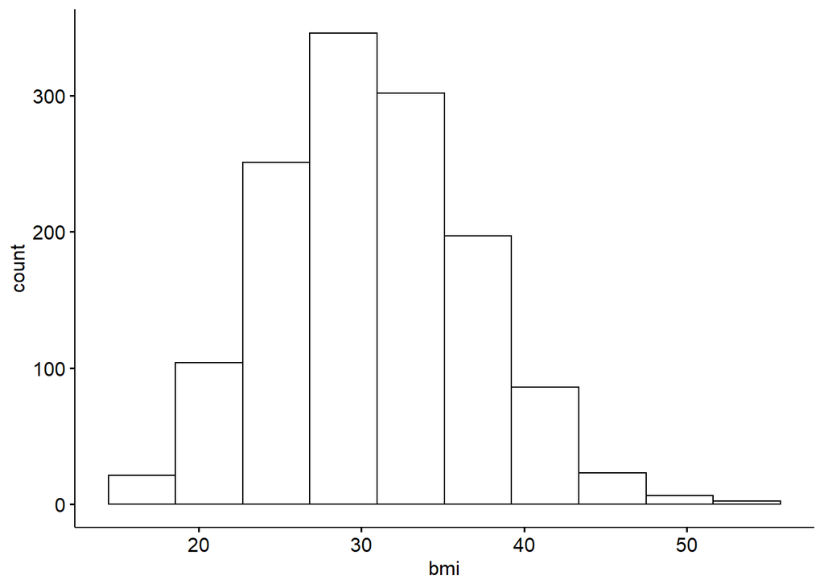

```r
library(ggpubr)
gghistogram(insurance, x = "bmi", bins = 10)
```

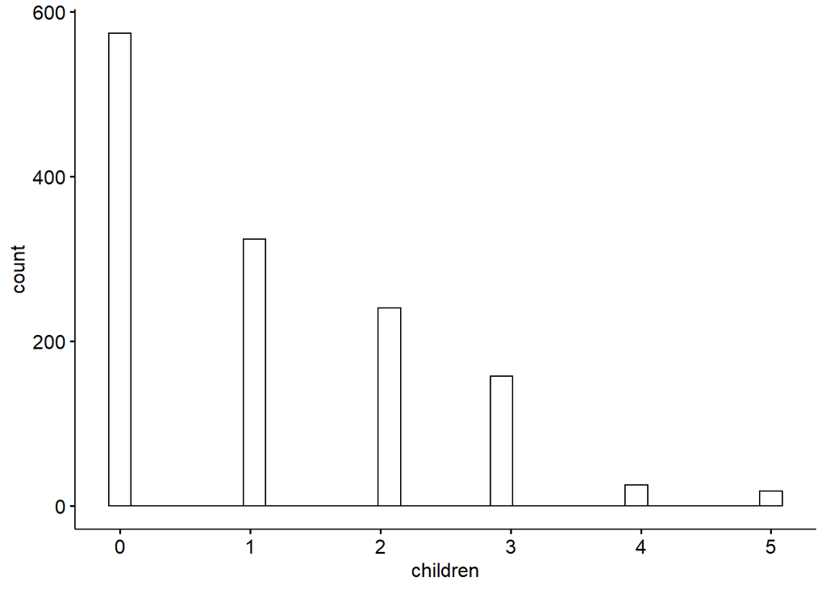

```r
gghistogram(insurance, x = "children")
```

### Funciones de densidad

De manera similar, podemos obtener gráficos de densidad de la siguiente manera:

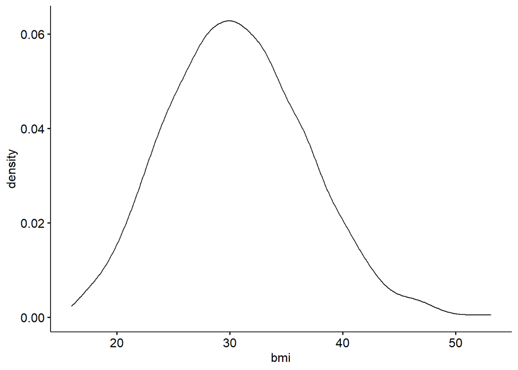

```r
ggdensity(insurance, x = "bmi")
```

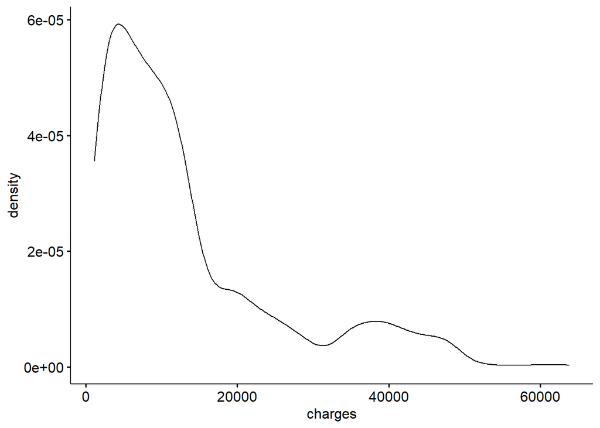

```r
ggdensity(insurance, x = "charges")
```

## Describiendo las distribuciones

### Medidas de posición

A continuación, describimos las medidas de posición más importantes:

- **Media**

```r
mean(insurance$bmi)
```

```
## [1] 30.6634
```

- **Mediana**

```r
median(insurance$bmi)
```

```
## [1] 30.4
```

- **Moda** R no tiene implementada una función moda como tal, por lo que la definimos a continuación:

```r
getmode <- function(v){
  uniqv <- unique(v)
  uniqv[which.max(tabulate(match(v, uniqv)))]
}

getmode(insurance$region)
```

```
## [1] southeast
## Levels: northeast northwest southeast southwest
```

- **Percentiles y cuartiles** Si no especificamos nada, la función `quantile` nos devolverá los percentiles 0, 25, 50, 75 y 100. En cambio, si los especificamos, nos devolverá únicamente estos.

```r
quantile(insurance$bmi)
```

```
##       0%      25%      50%      75%     100%
## 15.96000 26.29625 30.40000 34.69375 53.13000
```

```r
quantile(insurance$bmi, c(0.15, 0.85))
```

```
##      15%      85%
## 24.26625 37.05000
```

### Medidas de variabilidad

- **Rango**

```r
max(insurance$bmi) - min(insurance$bmi)
```

```
## [1] 37.17
```

- **Desviación típica**

```r
sd(insurance$bmi)
```

```
## [1] 6.098187
```

- **Varianza**

```r
sd(insurance$bmi)**2
```

```
## [1] 37.18788
```

- **Intervalo intercuartílico**

```r
IQR(insurance$bmi)
```

```
## [1] 8.3975
```

## Visualización de datos

### Gráfico de barras

Se puede encontrar a continuación algunos ejemplos de gráficos de barras realizados con `ggpubr`. Se muestra el coste de la póliza según si el individuo es fumador o no. En el primero, además, se marcará la media por categoría, mientras que en segundo se añade también la desviación típica.

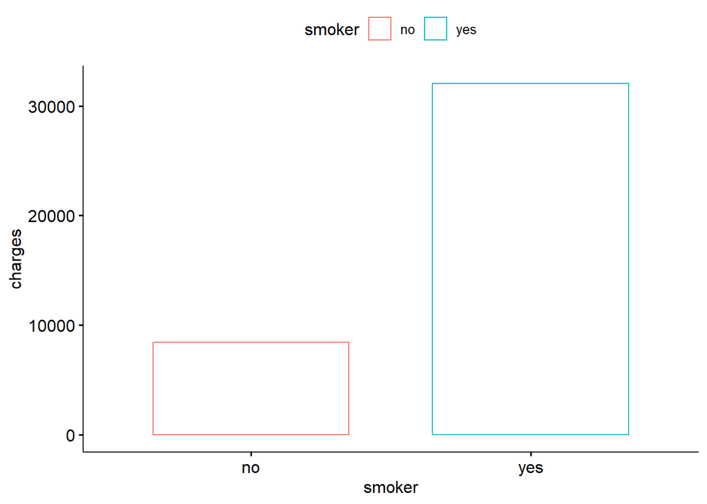

```r
insurance%>%ggbarplot(x = "smoker", y = "charges", color =
"smoker", add = "mean")
```

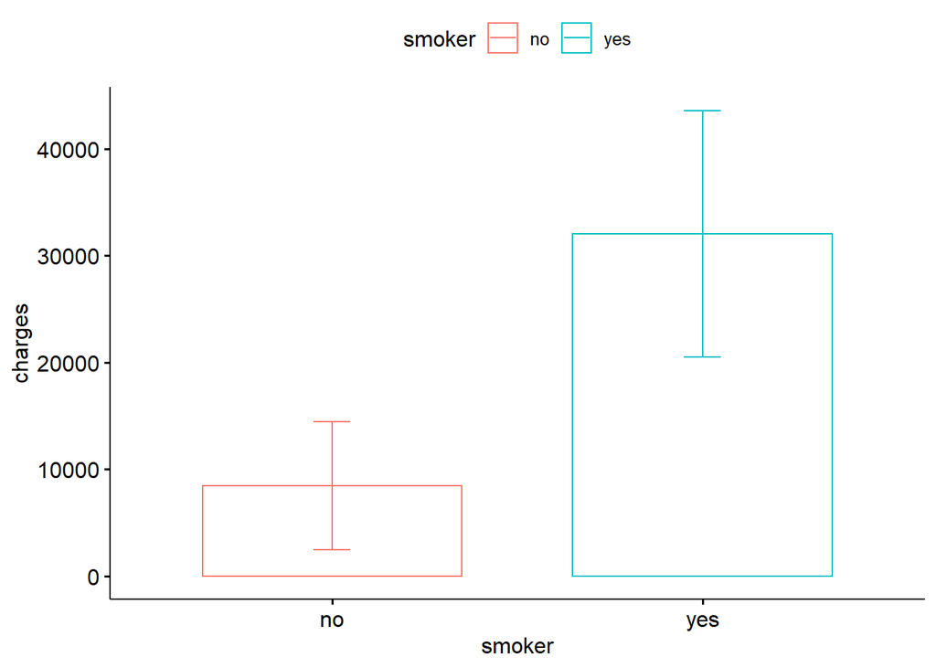

```r
insurance%>%ggbarplot(x = "smoker", y = "charges", color =
"smoker", add = "mean_sd")
```

### Boxplot

Los *boxplots* tienen las siguientes características

- La caja central, que presenta el rango desde $Q_1$ a $Q_3$ o intervalo intercuartílico (IQR).
- La mediana, coincidente con el $Q_2$, mostrada como una línea dentro de la caja.
- Los bigotes, que cubren la distancia hasta el valor más bajo y más alto, pero sin sobrepasar 1.5 veces el valor de $Q_1$ y $Q_3$, respectivamente. Cualquier punto más allá se considerará un valor atípico.
- Valores atípicos, que se dibujan como puntos más allá de los bigotes. No siempre aparecen, pero tampoco tienen que considerarse directamente como valores extremos si existen. Es decir, estos valores no son automáticamente descartados del análisis.
- Se puede incorporar, de manera opcional, la media como un punto que generalmente se encontrará dentro de la caja central. De hacerlo, serviría para definir parte de la forma de la distribución de los datos. En concreto, su asimetría.

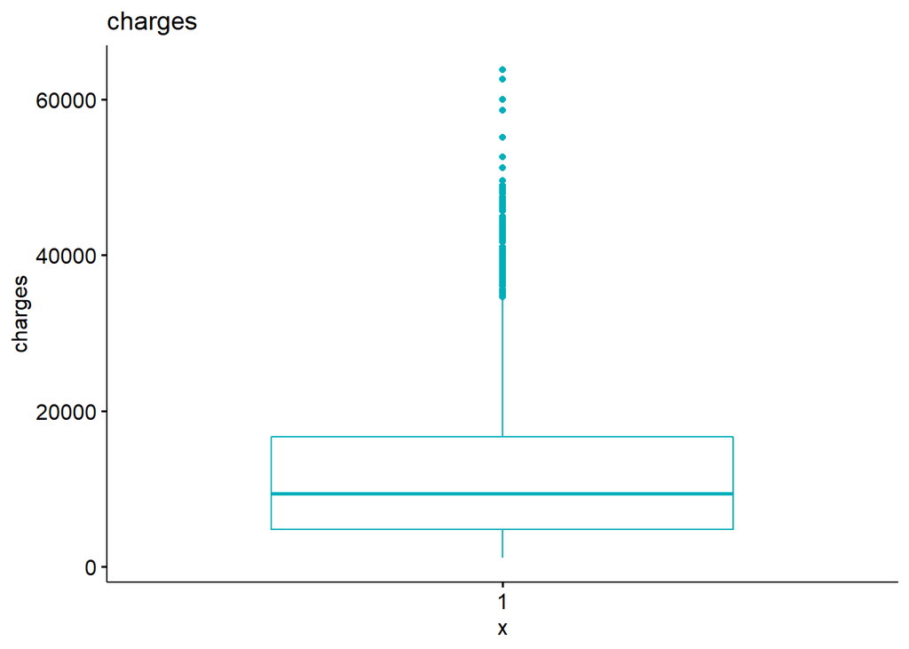

```r
library(ggpubr)
ggboxplot(insurance, y = "charges", color = "#00AFBB",
    title = "charges")
```

Además de los *boxplots*, también tenemos los gráficos de violín, que sirven para dilucidar mejor la distribución real de las variables. El *boxplot* y el gráfico de violín se pueden combinar como se ve a continuación, mediante el parámetro `add`.

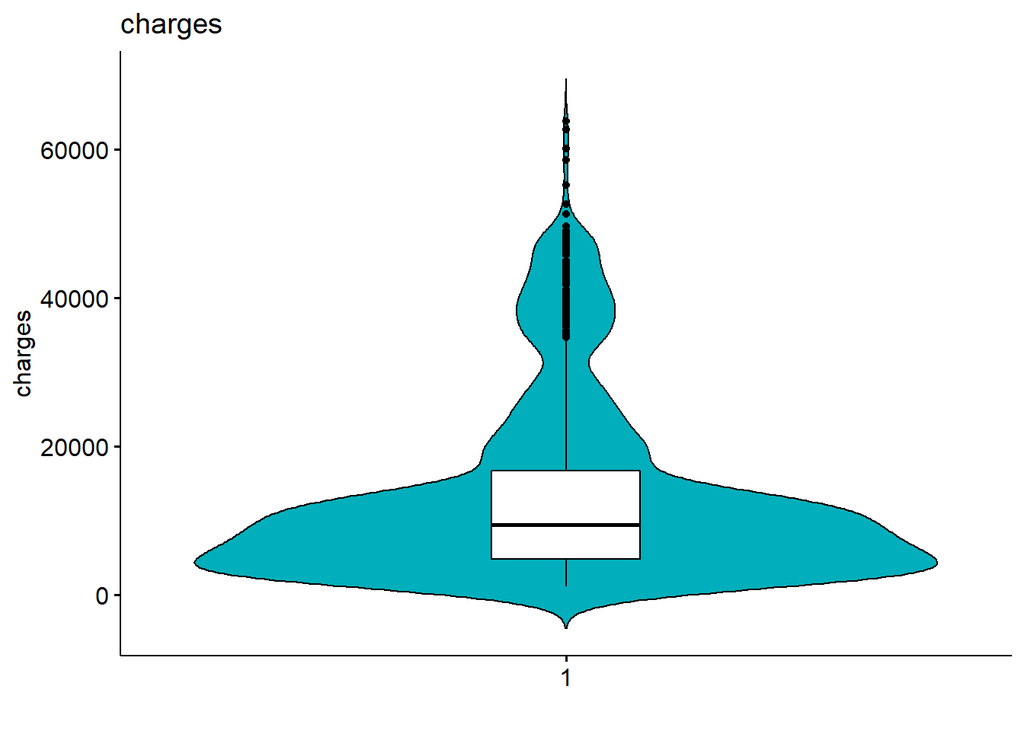

```r
ggviolin(insurance, y = "charges", color = "black",
fill = "#00AFBB", title = "charges", add = "boxplot",
add.params = list(fill = "white"), xlab = "")
```

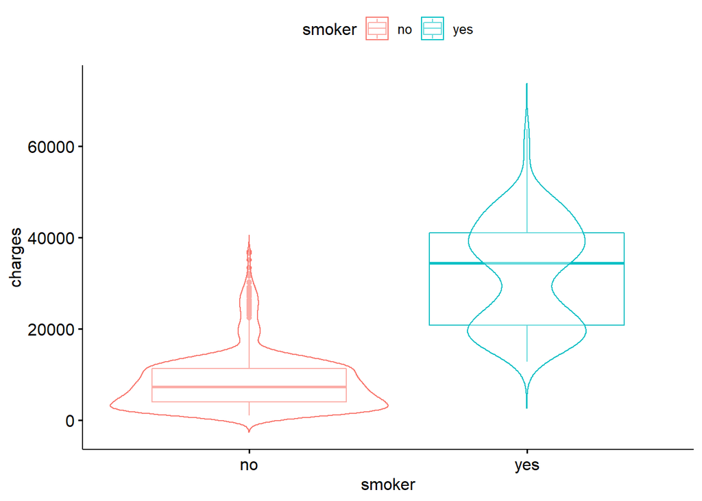

```r
ggboxplot(insurance, y = "charges", x = "smoker", color = "smoker", add = "violin", add.params = list(alpha = 0.4))
```

### Scatterplot

La librería `ggplot2` nos permite obtener *scatterplot*, o gráficos de dispersión, de manera sencilla, como se ve a continuación. La sintaxis de `ggplot2` es la siguiente: primero, se genera un gráfico vacio indicando el *dataset* de referencia, e indicando con el comando `aes` la variable que irá en el eje x y la del eje y. Una vez creado, se le dice que añada la geometría de puntos necesaria para crear un gráfico de dispersión.

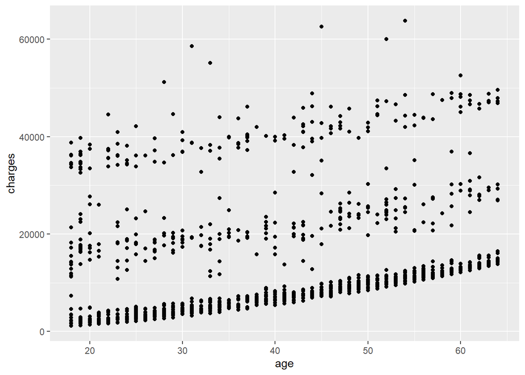

```r
ggplot(insurance, aes(x = age, y = charges))+
  geom_point()
```

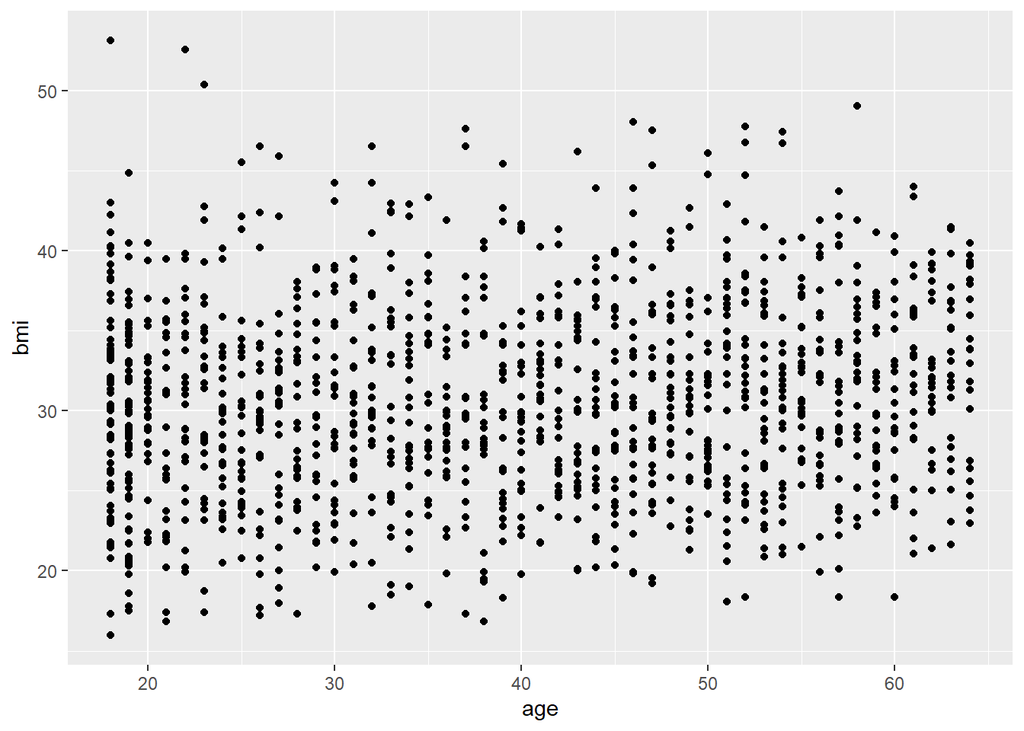

```r
ggplot(insurance, aes(x = age, y = bmi))+
  geom_point()
```

### Pie chart

El gráfico de tarta o *pie chart* lo crearemos con `ggplot2` como si fuera un gráfico de barras, pero después indicándole que las coordenadas donde aparecerán las barras deben ser polares, es decir, circulares.

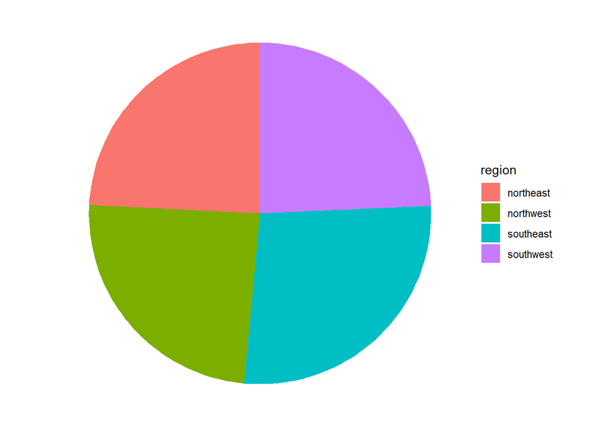

```r
insurance%>%group_by(region)%>%summarize(N = n())%>%
            ggplot(aes(x="", y=N, fill=region)) +
                geom_bar(stat="identity", width= 1) +
                coord_polar("y", start=0)+theme_void()
```

### Combinar gráficos

Se pueden combinar distintos gráficos mediante la librería `patchwork`. Para ello, es necesario asignar cada gráfico a una variable diferente, como se ve a continuación.

```r
library(patchwork)
```

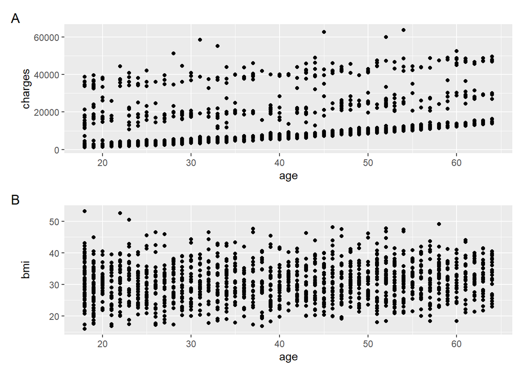

```r
p1 <- ggplot(insurance, aes(x = age, y = charges))+
  geom_point()
p2 <- ggplot(insurance, aes(x = age, y = bmi))+
  geom_point()

p1/p2 + plot_annotation(tag_levels = "A")
```

### Exportar gráficos

Finalmente, una vez hayamos modificado el gráfico como queramos, lo podremos exportar de las siguientes maneras:

- **ggsave**

Se puede guardar con diferentes extensiones cambiando el `.jpg` por `.png` o `.pdf`.

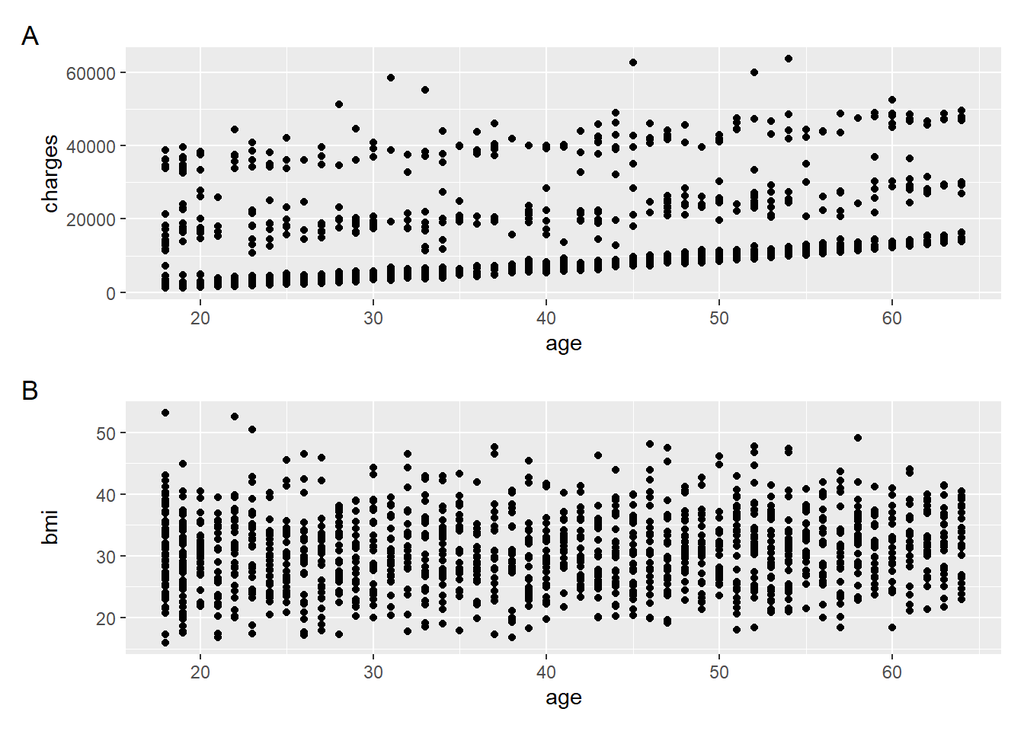

```r
p1/p2 + plot_annotation(tag_levels = "A")
```

```r
ggsave("./NombreFigura.jpg", width = 10, height = 5,
            units = "cm")
```

- **r base**

Se puede guardar con diferentes extensiones cambiando el `jpeg()` por `png()` o `pdf()`.

```r
jpeg()
p1/p2 + plot_annotation(tag_levels = "A")
dev.off()
```

# Capítulo 4. La distribución normal

## La distribución normal y la distribución normal tipificada

```r
distrib_normal_tipif = rnorm(1000) # Distribución normal tipificada de 1000 elementos

distrib_normal = rnorm(1000, mean = 5, sd = 2) # Distribución normal de 1000 elementos
```

Esta distribución normal tiene, apróximadamente, las especificaciones que le hemos dado.

```r
mean(distrib_normal)
```

```
## [1] 5.084931
```

```r
sd(distrib_normal)
```

```
## [1] 2.019348
```

Si quisieramos tipificarla, lo podríamos hacer mediante la función `scale`:

```r
distrib_normal_tipif <- scale(distrib_normal)

mean(distrib_normal_tipif)
```

```
## [1] 4.738232e-17
```

```r
sd(distrib_normal_tipif)
```

```
## [1] 1
```

Como se podía esperar, la nueva media es prácticamente 0, y la desviación típica es 1.

El siguiente código permite obtener la Figura 4.1, dibujando la distribución real de una variable, y la que tendría una distribución normal con sus mismos parámetros. Primero, crearemos un `data.frame` temporal con la información de la distribución normal (`rnorm`) que hemos creado con los parámetros de la real (`insurance$bmi`). Primero crearemos un `ggplot` con los datos reales. A este le incorporaremos el histograma y la línea de densidad, índicandole en el `aes` que en la leyenda queremos que aparezca ese color asociado a la distribución real. Después de unos parámetros de estilo relacionados con el tema de visualización, añadimos una nueva línea de densidad con los datos del `data.frame` temporal, y asociamos ese nuevo color a la distribución ideal. Finalmente, ponemos el título de la gráfica.

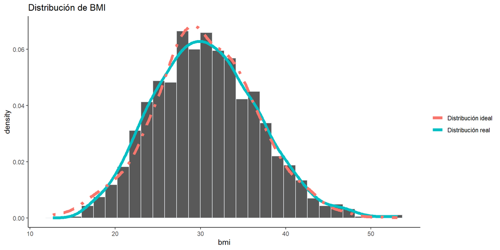

```r
temp = data.frame(x = rnorm(nrow(insurance), mean = mean(insurance$bmi), sd = sd(insurance$bmi)))

ggplot(insurance, aes(x = bmi))+
  geom_histogram(aes(y =stat(density)), color="#e9ecef")+
  geom_line(stat = "density", aes(col = "Distribución real"), lwd = 2)+
  theme_classic()+
  theme(legend.title = element_blank())+
  geom_line(aes(x = temp$x, col = "Distribución ideal"), stat = "density", lwd = 2, linetype = 4) +
  ggtitle("Distribución de BMI")
```

## Análisis de normalidad

A continuación, creamos una variable normal que hará referencia al número de horas sentadas que pasa cada persona. La media será de 8 horas, y la desviación típica de 2. Esta variable ha de tener tantos valores como número de personas hay en el conjunto de datos.

```r
numeroPersonas = nrow(insurance)
insurance$SittingHours = rnorm(numeroPersonas, mean = 8, sd = 2)
```

### QQ-plot

El qq-plot es un gráfico que nos permite estudiar la normalidad de una variable de manera gráfica. Para generar la Figura 4.3 del libro, lo hacemos con el siguiente código. La función `qqline` necesita dos parámetros básicos: una distribución normal tipificada y la variable real.

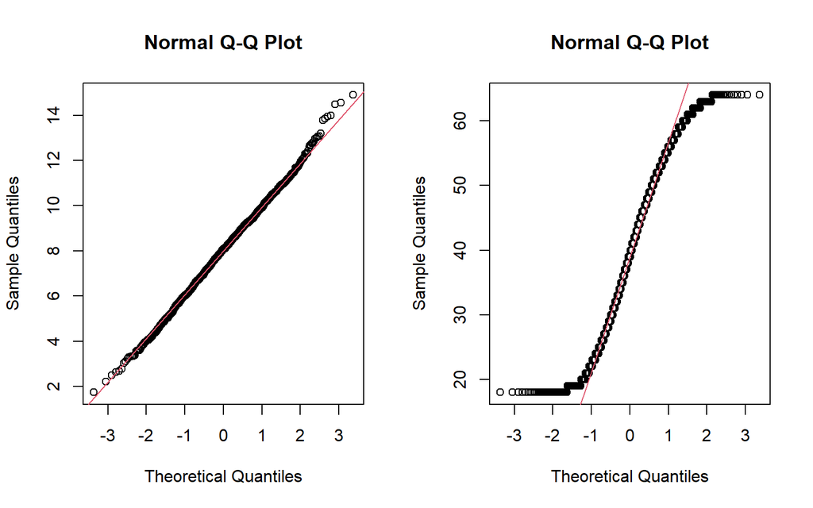

```r
par(mfrow = c(1, 2)) # Para que aparezcan uno al lado del otro
qqnorm(insurance$SittingHours)
qqline(insurance$SittingHours, col = 2)

qqnorm(insurance$age)
qqline(insurance$age, col = 2)
```

```r
par(mfcol = c(1, 1))
```

## Otras distribuciones

### Distribuciones discretas

**Binomial**

La función `dbinom` nos permite generar una distribución binomial. El primer parámetro que introduciremos (`x`) será el número de éxitos que queremos tener, el siguiente (`size`) es el número de intentos que realizaremos, y el tercero (`prob`) será la probabilidad de éxito de cada intento. Por ejemplo, la probabilidad de obtener 2 caras tirando 6 veces una moneda es la siguiente:

```r
dbinom(2, 6, 0.5)
```

```
## [1] 0.234375
```

Para generar la Figura 4.4 se necesita calcular las probabilidades asociadas a varios números de éxitos. Por ejemplo, calculamos entre 1 y 100 éxitos (`1:100`), suponiendo que hacemos 100 tiradas.

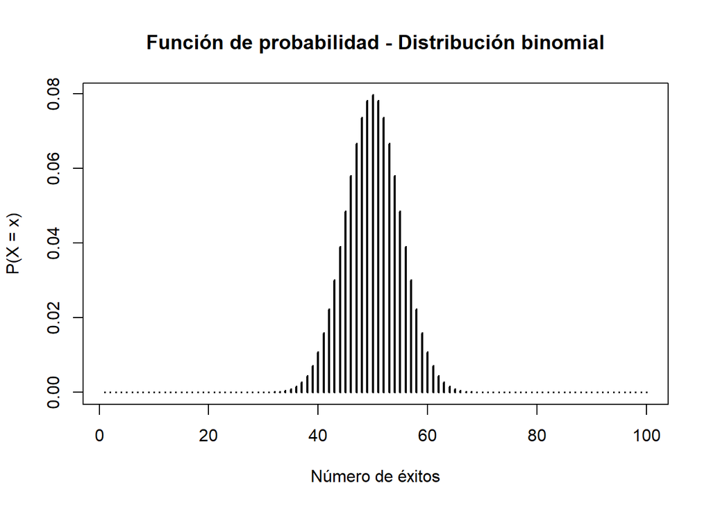

```r
plot(dbinom(1:100, size = 100, prob = 0.5), type = "h", lwd = 2,
     main = "Función de probabilidad - Distribución binomial",
     ylab = "P(X = x)", xlab = "Número de éxitos")
```

- **Poisson**

En el caso de la Poisson (`dpois`), necesitaremos dos hiperparámetros: el número de ocurrencias que queremos observar (`x`) y el número medio de ocurrencias en el tiempo de estudio (`lambda`). Por ejemplo, si queremos estudiar la probabilidad de tener 10 fallos durante una hora en una cadena de montaje, teniendo en cuenta que se suelen producir unos 25 fallos a la hora.

```r
dpois(10, 25)
```

```
## [1] 0.000364985
```

Como se ve, la probabilidad de que ocurran 10 fallos en una hora, cuando lo normal es que ocurran 25, es muy baja.

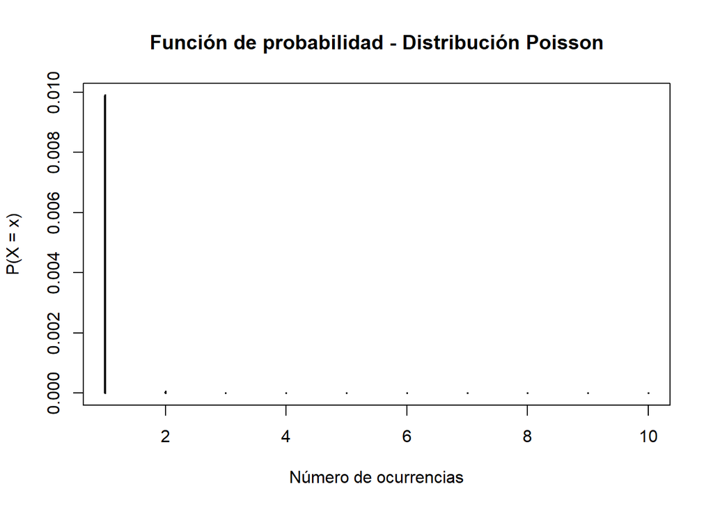

```r
plot(dpois(1:10, lambda = 0.01), type = "h", lwd = 2,
     main = "Función de probabilidad - Distribución Poisson",
     ylab = "P(X = x)", xlab = "Número de ocurrencias")
```

### Distribuciones continuas

- **Exponencial**

Para una distribución exponencial (`dexp`), también necesitaremos dos parámetros: el tiempo a analizar (`x`) y el parámetro lambda de la distribución de Poisson (`rate`). Por ejemplo, si queremos estimar la probabilidad de que el primer fallo en la cadena de montaje (λ = 25) ocurra a la media hora, la probabilidad será pequeña.

```r
dexp(0.5, 25)
```

```
## [1] 9.316633e-05
```

La Figura 4.6 se puede obtener con el siguiente código. Generaremos una secuencia de tiempos entre 0 y 8, separados por 0.1 unidades de tiempo. Genearemos la distribución con la lambda igual a 2, y añadiremos una línea adicional con la lambda igual a 1.

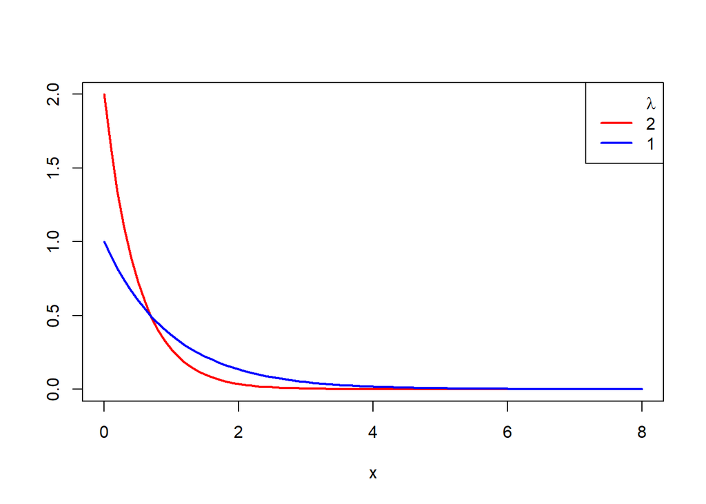

```r
x <- seq(0, 8, 0.1)


plot(x, dexp(x, 2), type = "l", ylab = "", lwd = 2, col = "red")# lambda = 2
lines(x, dexp(x, rate = 1), col = "blue", lty = 1, lwd = 2)# lambda = 1
legend("topright",
       c(expression(lambda), "2", "1"),
       lty = c(0, 1, 1),
       col = c("blue", "red"),
       box.lty = 1, lwd = 2)  # Añadimos la leyenda
```

- **t de Student**

En el caso de la distribución t-Student, los valores dependerán de los grados de libertad (gl, o `df`) que se le de. El siguiente código permite obtener la Figura 4.7.

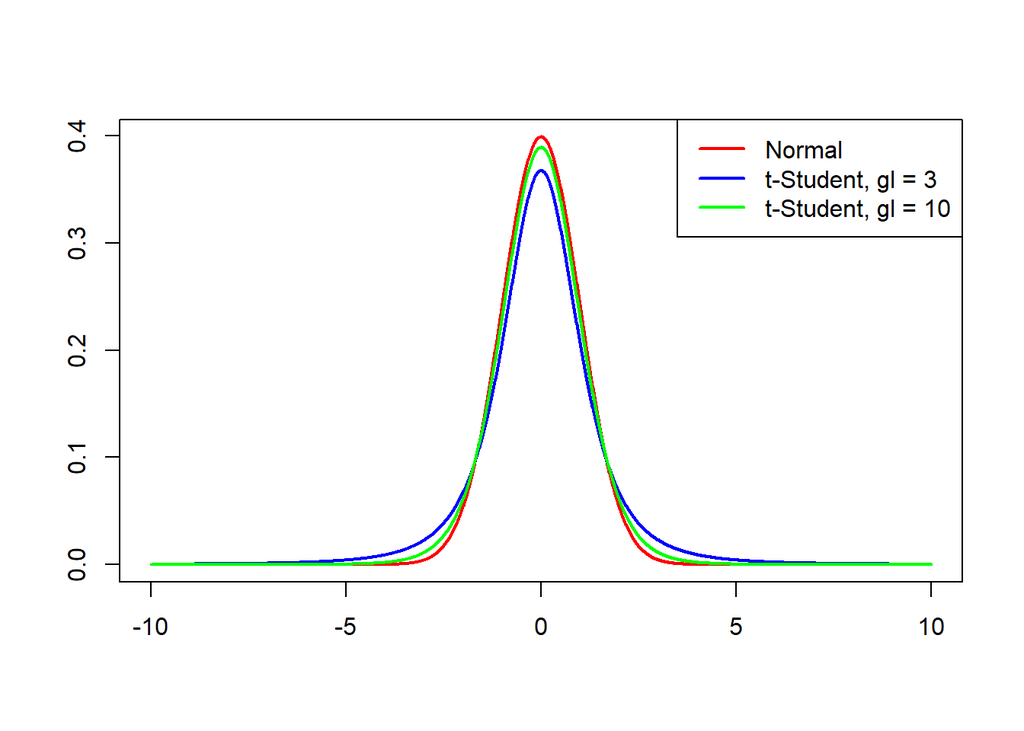

```r
tStudent <- dt(seq(- 10, 10, by = 0.01), df = 3)
tStudent10 <- dt(seq(- 10, 10, by = 0.01), df = 10)
norm <- dnorm(seq(-10, 10, 0.01))

plot(seq(-10, 10, 0.01), dnorm(seq(-10, 10, 0.01)), type = "l", col = "red",lty = 1, lwd = 2, xlab = "", ylab = "")
lines(seq(-10, 10, 0.01), tStudent, col = "blue", type = "l",lty = 1, lwd = 2)
lines(seq(-10, 10, 0.01), tStudent10, col = "green", type = "l",lty = 1, lwd = 2)
legend("topright", legend = c("Normal", "t-Student, gl = 3", "t-Student, gl = 10"), col = c("red", "blue", "green"),lty = 1, lwd = 2)
```

- **Chi-cuadrado**

De manera similar a la anterior, esta distribución varia con los grados de libertad que se le de. Para obtener la Figura 4.8, utilizamos el siguiente código.

[figure not shown]

```r
x <- seq(0, 20, 0.1)

plot(x, dchisq(x, df = 5), type = "l", ylab = "", lwd = 2, col = "red")
lines(x, dchisq(x, df = 10), col = "blue", lty = 1, lwd = 2)
legend("topright", c("Grados de libertad", "10", "5"), lty = c(0, 1.5, 1), col = c("blue", "red"), box.lty = 1, lwd = 2)
```

# Capítulo 5. Contraste de hipótesis

Este capítulo del libro es básicamente teórico, por lo que pondremos todo el código relacionado con los contrastes de hipótesis en el siguiente capítulo.

## Tamaño de efecto, poder estadístico y tamaño de muestra

El tamaño de efecto y el poder estadístico son dos conceptos que se explican en el libro y que necesitaremos comprender para hacer el cálculo del tamaño muestral, por lo que se recomienda la lectura de la sección 5.10 de este capítulo. A continuación, ponemos algunos ejemplos de código para realizar el cálculo del tamaño muestral. Recomendamos la lectura de la web [https://www.statmethods.net/stats/power.html], donde aparecen la mayoría de posibilidades para realizar estos cálculos en R, pues la función que necesitaremos para el cálculo dependerá del tipo de contraste de hipótesis que queramos hacer en nuestro estudio. Todas estas funciones están dentro de la librería `pwr`, que deberemos instalar previamente.

Por ejemplo, para calcular el tamaño muestral necesario para realizar un t-test con un tamaño de efecto pequeño ($`d = 0.2`$), un poder estadístico alto ($\beta = 0.8$) y un nivel de significatividad estándar ($\alfa = 0.05$), utilizaríamos el siguiente código:

```r
library(pwr)
pwr.t.test(d = 0.2, sig.level = 0.05, power = 0.8)
```

```
##
##      Two-sample t test power calculation
##
##               n = 393.4057
##               d = 0.2
##       sig.level = 0.05
##           power = 0.8
##     alternative = two.sided
##
## NOTE: n is number in *each* group
```

Esta función nos indica que necesitaríamos al menos 394 muestras en cada grupo. En cambio, si las diferencias que esperamos encontrar entre los dos grupos son más grandes ($d = 0.8$), sólo necesitaríamos 26 muestras en cada grupo.

```r
pwr.t.test(d = 0.8, sig.level = 0.05, power = 0.8)
```

```
##
##      Two-sample t test power calculation
##
##               n = 25.52458
##               d = 0.8
##       sig.level = 0.05
##           power = 0.8
##     alternative = two.sided
##
## NOTE: n is number in *each* group
```

Si en vez de un t-test quisieramos hacer un ANOVA utilizaríamos la función `pwr.anova.test`. En ella hemos de indicar todas menos una de las siguientes variables: el número de grupos (`k`), el número de muestras por grupo (`n`), el tamaño de efecto (`f`), el nivel de significatividad (`sig.level`) o el poder estadístico (`power`). Por ejemplo, si tenemos un contraste de 5 grupos, en el que queremos tener un tamaño de efecto pequeño, un nivel de significatividad estándar y un buen poder estadístico, necesitariamos al menos 61 muestras en cada uno de los 5 grupos.

```r
pwr.anova.test(k = 5, f = 0.2, sig.level = 0.05, power = 0.8)
```

```
##
##      Balanced one-way analysis of variance power calculation
##
##               k = 5
##               n = 60.63274
##               f = 0.2
##       sig.level = 0.05
##           power = 0.8
##
## NOTE: n is number in each group
```

# Capítulo 6. Tests estadísticos

## Contrastes de una variable

### Contrastes para una proporción

Para calcular si la proporción de mujeres de nuestros datos es apróximadamente de 0.5, necesitamos utilizar el `prop.test`, indicándole el número de mujeres, el número total de individuos, y la proporción que queremos comprobar.

```r
n_mujeres <- sum(insurance$sex == "female")
n_total <- nrow(insurance)
prop.test(n_mujeres, n_total, p = 0.5)
```

```
##
##  1-sample proportions test with continuity correction
##
## data:  n_mujeres out of n_total, null probability 0.5
## X-squared = 0.12631, df = 1, p-value = 0.7223
## alternative hypothesis: true p is not equal to 0.5
## 95 percent confidence interval:
##  0.4676597 0.5219073
## sample estimates:
##         p
## 0.4947683
```

En este caso, el p-valor del test es de 0.72, lo cual nos indica que es muy probable que encontremos una proporción de mujeres de 0.5 y que, por lo tanto, no podamos rechazar la hipótesis nula. El intervalo de confianza nos revela que la proporción real de mujeres en la población se encontrará en el intervalo $p_{mujeres` \in [0.4677, 0.5219]$. Para calcular el tamaño de efecto asociado al test, necesitaremos instalar la librería `effectsize` y utilizar el siguiente código, en el cual le indicamos a la función las frecuencias absolutas de cada sexo y las que queremos contrastar

```r
library(effectsize)
pearsons_c(table(insurance$sex), p = c(0.5, 0.5))
```

| Pearsons_c | CI | CI_low | CI_high |
| --- | --- | --- | --- |
| 0.0104628 | 0.95 | 0 | 1 |

Es un tamaño de efecto pequeño.

### Contraste para una media

Queremos estudiar si la media de horas que pasan los individuos sentados es de 5.5 horas. En las variables numéricas necesitamos comprobar si se distribuyen normalmente o no, para aplicar tests paramétricos o no paramétricos. Para ello podemos utilizar el `shapiro.test` en la mayoría de ocasiones.

```r
shapiro.test(insurance$SittingHours)
```

```
##
##  Shapiro-Wilk normality test
##
## data:  insurance$SittingHours
## W = 0.99866, p-value = 0.4031
```

Como esta variable es normal (p-valor > 0.05), procedemos a hacer un t-test tal y como se ve a continuación. Utilizamos el parámetro `mu` para indicar el valor de la media que nosotros queremos contrastar.

```r
t.test(insurance$SittingHours, mu = 5.5)
```

```
##
##  One Sample t-test
##
## data:  insurance$SittingHours
## t = 46.06, df = 1337, p-value < 2.2e-16
## alternative hypothesis: true mean is not equal to 5.5
## 95 percent confidence interval:
##  7.890548 8.103239
## sample estimates:
## mean of x
##  7.996893
```

Como el p-valor es muy pequeño, descartamos esta hipótesis. Si quisiéramos conocer el tamaño de efecto, utilizaríamos la función `cohens_d` de la librería `effectsize`.

```r
cohens_d(x = "SittingHours", y = 5.5, data = insurance)
```

| Cohens_d | CI | CI_low | CI_high |
| --- | --- | --- | --- |
| 1.2592 | 0.95 | -0.702312 | 3.220242 |

Es un tamaño de efecto grande.

### Contraste para una varianza

```r
TeachingDemos::sigma.test(insurance$SittingHours, sigma = 4, alternative = "greater")
```

```
##
##  One sample Chi-squared test for variance
##
## data:  insurance$SittingHours
## X-squared = 328.57, df = 1337, p-value = 1
## alternative hypothesis: true variance is greater than 16
## 95 percent confidence interval:
##  3.693878      Inf
## sample estimates:
## var of insurance$SittingHours
##                      3.931972
```

## Contraste para proporciones de más de una variable

### Test de independencia Chi-cuadrado

Para realizar este test utilizamos los datos de los pasajeros del Titanic que están disponibles para descargar en Kaggle (https://www.kaggle.com/competitions/titanic/). Queremos comprobar si hay una relación entre la clase en la que viajaba cada uno (`Pclass`) y si sobrevivieron o no ( `Survived`).

```r
data = read.csv("train.csv")
supervivencia = data$Survived
clase = data$Pclass
chisq.test(supervivencia, clase)
```

```
##
##  Pearson's Chi-squared test
##
## data:  supervivencia and clase
## X-squared = 102.89, df = 2, p-value < 2.2e-16
```

Se puede decir que hay una dependencia entre la supervivencia y la clase en la que viajaban. El tamaño de efecto asociado a este test se calcula con `cramers_v` de `effectsize`, tal y como se ve a continuación:

```r
library(effectsize)
cramers_v(supervivencia, clase)
```

| Cramers_v | CI | CI_low | CI_high |
| --- | --- | --- | --- |
| 0.3398174 | 0.95 | 0.2829019 | 1 |

Finalmente, si quisieramos visualizar la distribución de la supervivencia por clase, R ofrece la función `mosaicplot` para ello. El parametro `shade = T` permite colorear los diferentes rectángulos según la diferencia entre la frecuencia esperada (en el caso de que la supervivencia no dependiera de la clase) y la observada en la realidad. El color azul implica tener una mayor frecuencia observada que esperada, es decir, que es un hecho que ocurre más de lo que debería. El color rojo, por otro lado, expresa una diferencia negativa entre la frecuencia esperada y la observada, por lo que marcará combinaciones de condiciones que ocurren menos de lo esperado.Se utiliza de la siguiente manera:

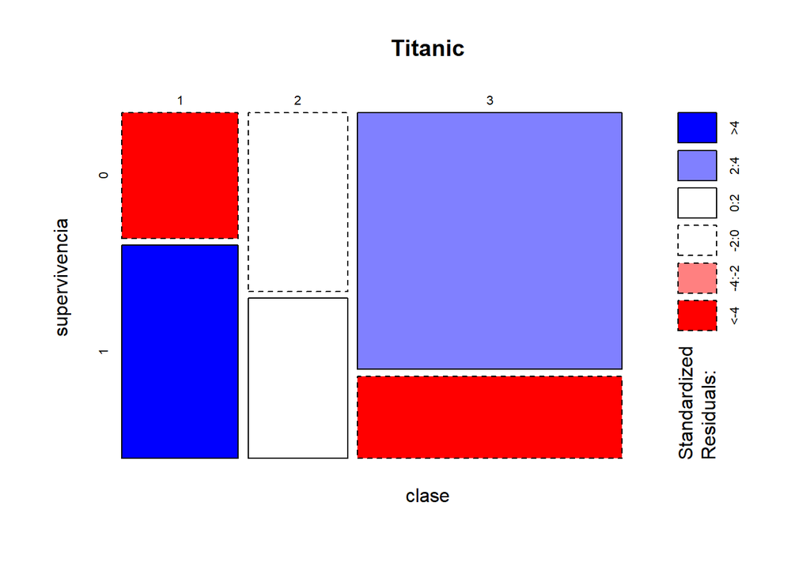

```r
Titanic = table(clase, supervivencia)
mosaicplot(Titanic, shade = T)
```

Hay más personas de lo esperable de tercera clase que no sobrevivieron, mientras que más personas de primera clase de las esperables sí lo hicieron.

### Test McNemar

El test McNemar es también un contraste de proporciones, pero se utiliza cuando tenemos dos muestras provenientes del mismo individuo u origen en momentos temporales diferentes. Por ejemplo, vamos a comparar las opiniones de los clientes de un supermercado tras el cambio de ubicación de los productos. Para ello, generaremos un pequeño conjunto de datos donde se tiene la respuesta de 50 personas a la pregunta *¿Le resulta fácil encontrar los productos que desea adquirir durante su compra?* en el estado inicial de un supermercado y tras el cambio de ubicación de los productos.

```r
set.seed(13)
data <- data.frame(IDComprador = 1:50,
                   RespuestaAntes = sample(c("Sí", "No", "No"), size = 50, replace = T),
                   RespuestaDespues = sample(c("Sí", "Sí","No"), size = 50, replace = T))


table(x = data$RespuestaAntes, y = data$RespuestaDespues, dnn = c("Antes", "Después"))
```

```
##      Después
## Antes No Sí
##    No 11 23
##    Sí  4 12
```

Realizamos el test de la siguiente manera. La función asume que las observaciones están apareadas, es decir, que el primer valor de la columna `RespuestaAntes` y el primer valor de `RespuestaDespues` provienen de la misma persona.

```r
mcnemar.test(x = data$RespuestaAntes, y = data$RespuestaDespues)
```

```
##
##  McNemar's Chi-squared test with continuity correction
##
## data:  data$RespuestaAntes and data$RespuestaDespues
## McNemar's chi-squared = 12, df = 1, p-value = 0.000532
```

```r
library(effectsize)
cohens_g(x = data$RespuestaAntes, y = data$RespuestaDespues)
```

| Cohens_g | CI | CI_low | CI_high |
| --- | --- | --- | --- |
| 0.3518519 | 0.95 | 0.1752131 | 0.4408407 |

## Contraste para medias: test de una variable y dos condiciones

### t-test

Como ejemplo de utilización de este test se va a estudiar si existe diferencia estadística en el peso (`weight`) debido al sexo en un grupo de personas que consta de 20 mujeres y 20 hombres. Para ello utilizaremos el conjunto de datos de `genderweight` del paquete `datarium`. Antes de realizar el test tenemos que comprobar que se cumplen los requisitos necesarios para hacerlo. Primero, que el peso (`weight`) se distribuye normalmente en los dos grupos que definimos. Una vez confirmado, se verifica la homocedasticidad de la variable, también por grupos. Finalmente ejecutamos el test.

```r
data("genderweight", package = "datarium")
pesoHombres <- genderweight%>%filter(group == "M")%>%dplyr::select(weight)%>%unlist()
shapiro.test(pesoHombres)
```

```
##
##  Shapiro-Wilk normality test
##
## data:  pesoHombres
## W = 0.98634, p-value = 0.9886
```

```r
pesoMujeres <- genderweight%>%filter(group == "F")%>%dplyr::select(weight)%>%unlist()
shapiro.test(pesoMujeres)
```

```
##
##  Shapiro-Wilk normality test
##
## data:  pesoMujeres
## W = 0.93847, p-value = 0.2243
```

Tanto el peso de las mujeres como el de los hombres se distribuye normalmente.

```r
rstatix::levene_test(lm(weight ~ group, data = genderweight))
```

| df1 | df2 | statistic | p |
| --- | --- | --- | --- |
| 1 | 38 | 6.116973 | 0.0179747 |

El p-valor del test de homocedasticidad es menor a 0.05, por lo que se rechaza la hipótesis de homocedasticidad. Sin embargo, la función en R que realiza el t-test no obliga a que se cumpla esta condición, ya que implementa la versión de Welch que considera varianzas diferentes para los diferentes grupos. Si la cumpliera, se podría especificar añadiendo el parámetro `var.equal = TRUE` al llamar a la función.

```r
t.test(x = pesoHombres, y = pesoMujeres)
```

```
##
##  Welch Two Sample t-test
##
## data:  pesoHombres and pesoMujeres
## t = 20.791, df = 26.872, p-value < 2.2e-16
## alternative hypothesis: true difference in means is not equal to 0
## 95 percent confidence interval:
##  20.12353 24.53135
## sample estimates:
## mean of x mean of y
##  85.82612  63.49867
```

En efecto, hay una diferencia estadísticamente significativa entre los hombres y las mujeres. Para conocer el tamaño de efecto, lo calculamos de la siguiente manera:

```r
library(effectsize)
cohens_d(x = "weight", y = "group", data = genderweight)
```

| Cohens_d | CI | CI_low | CI_high |
| --- | --- | --- | --- |
| -6.574811 | 0.95 | -8.164377 | -4.969752 |

Aunque el valor que se obtiene es negativo, se ha de tomar el valor absoluto del mismo, por lo que la d de Cohen es de 6.58 y el tamaño de efecto asociado al p-valor obtenido es grande.

### t-test pareado

Como en el caso del McNemar, si tenemos muestras pareadas necesitaremos hacer un t-test especial. Vamos a utilizar el mismo ejemplo que con el test McNemar, pero ahora los clientes contestarán con una escala numérica a la pregunta *Puntúe del 1 al 10 la facilidad con la que encuentra los productos durante su compra*. En este caso, la hipótesis nula, que siempre se enuncia desde el punto de vista más conservador, sería que los clientes no han variado de opinión tras el cambio de ubicación de los productos. La alternativa, mientras tanto, defendería que sí se ha producido un cambio en su opinión.

Simulamos los datos para que sean normales, como se ve a continuación.

```r
set.seed(13)
numerosAleatorios = round(rnorm(50, mean = 5, sd = 3),1)
numerosAleatorios2 = round(rnorm(50, mean = 5, sd = 3),1)
data <- data.frame(IDComprador = 1:50,
                   RespuestaAntes = numerosAleatorios,
                   RespuestaDespues = numerosAleatorios2)
```

Hacemos el t-test indicando que las muestras son pareadas (`paired = TRUE`). La función asume que las observaciones están apareadas, es decir, que el primer valor de la columna `RespuestaAntes` y el primer valor de `RespuestaDespues` provienen de la misma persona.

```r
t.test(x = data$RespuestaAntes,
       y = data$RespuestaDespues,
       paired = T)
```

```
##
##  Paired t-test
##
## data:  data$RespuestaAntes and data$RespuestaDespues
## t = 0.35231, df = 49, p-value = 0.7261
## alternative hypothesis: true mean difference is not equal to 0
## 95 percent confidence interval:
##  -0.9690244  1.3810244
## sample estimates:
## mean difference
##           0.206
```

El test no sale significativo, pero si quisiéramos calcular el tamaño de efecto, lo podríamos hacer como hemos visto en el caso del t-test, pero también indicando que las muestras son pareadas (`paired = TRUE`).

```r
library(effectsize)
cohens_d(x = "RespuestaAntes", y = "RespuestaDespues", data = data, paired = TRUE)
```

| Cohens_d | CI | CI_low | CI_high |
| --- | --- | --- | --- |
| 0.0498241 | 0.95 | -0.2277845 | 0.3269263 |

### Wilcoxon-Mann-Whitney

Este test es la versión no paramétrica del t-test. Utilizamos el ejemplo del capítulo 5.9 a continuación, para comprobar si las mujeres pagan lo mismo que los hombres.

```r
costesMujeres = insurance$charges[insurance$sex == "female"]
costesHombres = insurance$charges[insurance$sex == "male"]
wilcox.test(costesMujeres,
            costesHombres,
            conf.int = T)
```

```
##
##  Wilcoxon rank sum test with continuity correction
##
## data:  costesMujeres and costesHombres
## W = 221304, p-value = 0.7287
## alternative hypothesis: true location shift is not equal to 0
## 95 percent confidence interval:
##  -929.0673  566.9229
## sample estimates:
## difference in location
##              -114.8947
```

No hay diferencias significativas, por lo que no se puede decir que el coste de la póliza dependa del sexo. Si hubieran aparecido diferencias significativas, el tamaño de efecto asociado se podría calcular de la siguiente manera:

```r
library(effectsize)
rank_biserial(x = "charges", y = "sex", data = insurance)
```

| r_rank_biserial | CI | CI_low | CI_high |
| --- | --- | --- | --- |
| -0.0109584 | 0.95 | -0.072728 | 0.050895 |

### Wilcoxon signed rank test

Este es el test para muestras no paramétricas pareadas. Vamos a utilizar el mismo caso que para el t-test pareado, pero esta vez sin forzar a que las respuestas dadas sean paramétricas. Igualmente, comprobamos la normalidad de las dos respuestas con el `shapiro.test`, que nos confirma que no son normales.

```r
numerosAleatorios =  sample(1:10, size = 50, replace = T)
numerosAleatorios2 =  sample(1:10, size = 50, replace = T)
data <- data.frame(IDComprador = 1:50,
                   RespuestaAntes = numerosAleatorios,
                   RespuestaDespues = numerosAleatorios2)

shapiro.test(data$RespuestaAntes)
```

```
##
##  Shapiro-Wilk normality test
##
## data:  data$RespuestaAntes
## W = 0.91589, p-value = 0.00168
```

```r
shapiro.test(data$RespuestaDespues)
```

```
##
##  Shapiro-Wilk normality test
##
## data:  data$RespuestaDespues
## W = 0.905, p-value = 0.0007058
```

Hacemos el test indicando que las muestras son pareadas (`paired = TRUE`). La función asume que las observaciones están apareadas, es decir, que el primer valor de la columna `RespuestaAntes` y el primer valor de `RespuestaDespues` provienen de la misma persona.

```r
wilcox.test(x = data$RespuestaAntes, y = data$RespuestaDespues, paired = T)
```

```
##
##  Wilcoxon signed rank test with continuity correction
##
## data:  data$RespuestaAntes and data$RespuestaDespues
## V = 660, p-value = 0.1083
## alternative hypothesis: true location shift is not equal to 0
```

El test no sale significativo, pero si quisiéramos calcular el tamaño de efecto, lo podríamos hacer como hemos visto en el caso del test de Wilcoxon previo, pero también indicando que las muestras son pareadas (`paired = TRUE`).

```r
library(effectsize)
rank_biserial(x = "RespuestaAntes", y = "RespuestaDespues", data = data, paired = TRUE)
```

| r_rank_biserial | CI | CI_low | CI_high |
| --- | --- | --- | --- |
| 0.2753623 | 0.95 | -0.0358158 | 0.5378637 |

## Contraste para medias: test de una variable con más de dos condiciones

A continuación se muestra el código necesario para generar la Figura 6.2, para continuar dando ejemplos de visualizaciones de datos más avanzadas con `ggplot2` y combinación de gráficas con `patchwork`.

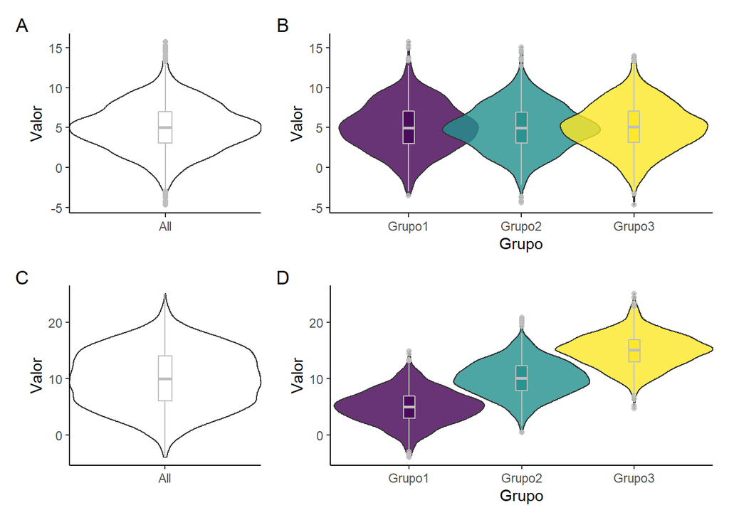

```r
#Primero creamos los datos artificales de 3 grupos, forzándolos a que sean distribuciones normales idénticas. La función gather reordena el data.frame en dos columnas: Grupo y Valor.
temp = data.frame(Grupo1 = rnorm(1000, mean = 5, sd = 3),
                  Grupo2 = rnorm(1000, mean = 5, sd = 3),
                  Grupo3 = rnorm(1000, mean = 5, sd = 3))%>%
  tidyr::gather(key = "Grupo", value = "Valor")

# Creamos un plot con la distribución general de los 3 grupos.
p1 <- ggplot(temp, aes(y = Valor, x = "All")) +
        geom_violin(width=1.4)+
        geom_boxplot(width=0.1, color="grey") +
        xlab("")+
        theme_classic()+
        theme(legend.position = "none")
# Creamos un plot que muestre la distribución de cada grupo por separado.
p2 <- ggplot(temp, aes(x = Grupo, y = Valor, fill = Grupo)) +
        geom_violin(width=1.4, alpha = 0.8)+
        geom_boxplot(width=0.1, color="grey", alpha=0.8) +
        viridis::scale_fill_viridis(discrete = TRUE) +
        theme_classic()+
        theme(legend.position = "none")

# Creamos los datos artificales de 3 grupos, forzándolos a que sean distribuciones normales pero con diferentes parámetros. La función gather reordena el data.frame en dos columnas: Grupo y Valor.

temp = data.frame(Grupo1 = rnorm(1000, mean = 5, sd = 3),
                  Grupo2 = rnorm(1000, mean = 10, sd = 3),
                  Grupo3 = rnorm(1000, mean = 15, sd = 3))%>%
  tidyr::gather(key = "Grupo", value = "Valor")
# Creamos un plot con la distribución general de los 3 grupos.
p3 <- ggplot(temp, aes(y = Valor, x = "All")) +
  geom_violin(width=1.4)+
  geom_boxplot(width=0.1, color="grey") +
  xlab("")+
  theme_classic()+
  theme(legend.position = "none")
# Creamos un plot que muestre la distribución de cada grupo por separado.
p4 <- ggplot(temp, aes(x = Grupo, y = Valor, fill = Grupo)) +
  geom_violin(width=1.4, alpha = 0.8)+
  geom_boxplot(width=0.1, color="grey", alpha=0.8) +
  viridis::scale_fill_viridis(discrete = TRUE) +
  theme_classic()+
  theme(legend.position = "none")

(p1 + p2+ plot_layout(widths = c(1,2))) / (p3+p4+ plot_layout(widths = c(1,2)))+ plot_annotation(tag_levels = "A")
```

### ANOVA

Para ejemplificar el uso del test ANOVA se va a comprobar si hay diferencias en el peso de plantas a las que se le han aplicado diferentes tratamientos, teniendo un grupo de control y dos tratamientos diferentes. La hipótesis nula sería que el tratamiento no influye y que, por lo tanto, el peso de las plantas es el mismo en todos los grupos. La hipótesis alternativa indica que el tratamiento sí tiene alguna influencia, por lo que el peso medio de las plantas de al menos un grupo será diferente al de los demás. Una vez cargados los datos, haremos una visualización sencilla para entender la distribución de los datos. También ponemos el código de una visualización más avanzada, similar a la anterior.

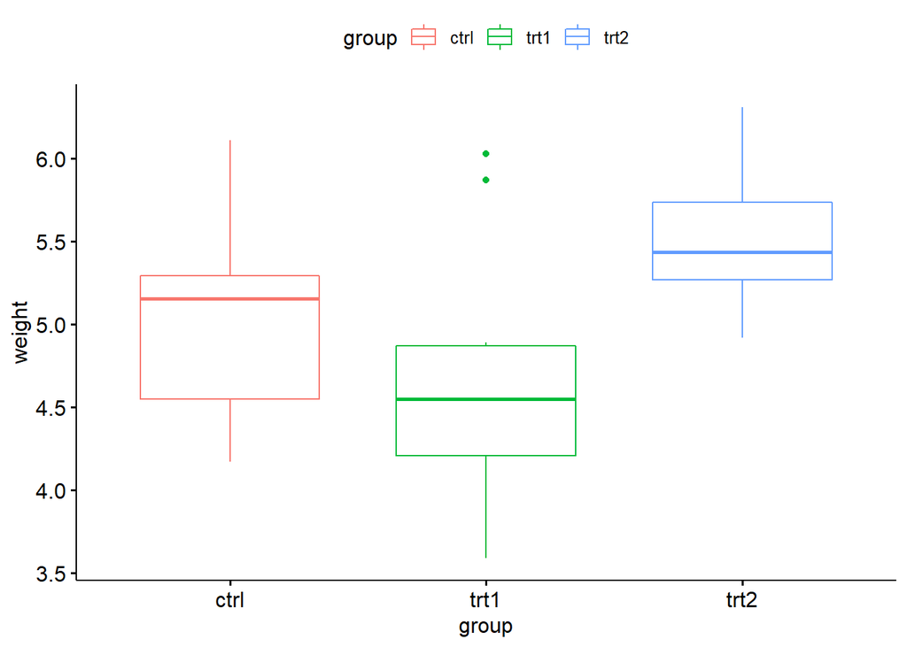

```r
data("PlantGrowth")
ggpubr::ggboxplot(PlantGrowth, x = "group", y = "weight", col = "group")
```

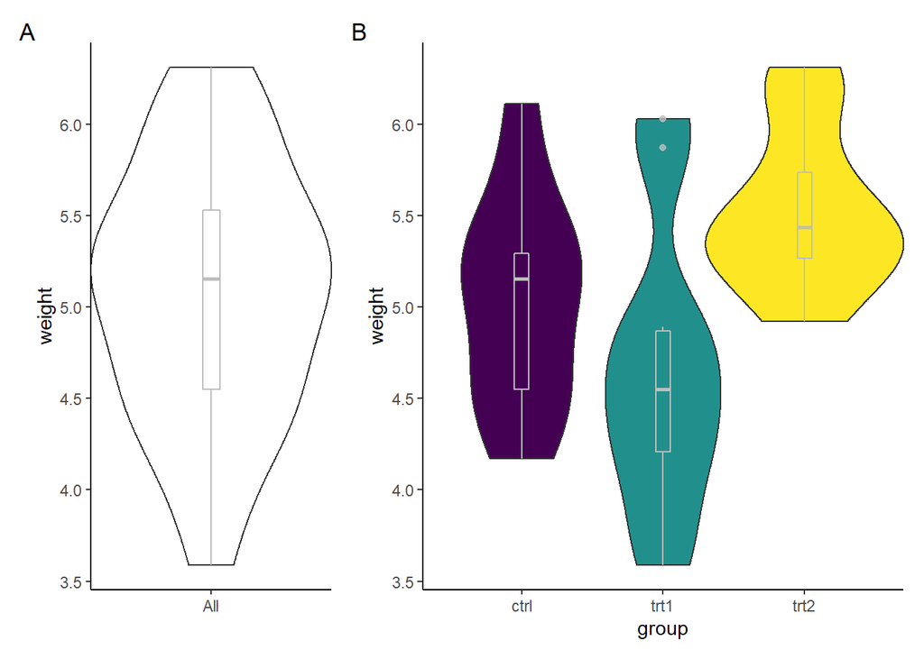

```r
p2 <- ggplot(PlantGrowth, aes(x = group, y = weight, fill = group)) +
  geom_violin(width=1.4)+
  geom_boxplot(width=0.1, color="grey", alpha=0.8) +
  viridis::scale_fill_viridis(discrete = TRUE) +
  theme_classic()+
  theme(legend.position = "none")
p1 <- ggplot(PlantGrowth, aes(y = weight, x = "All")) +
  geom_violin(width=1.4)+
  geom_boxplot(width=0.1, color="grey") +
  xlab("")+
  theme_classic()+
  theme(legend.position = "none")

p1 + p2 + plot_layout(widths = c(1,2))+plot_annotation(tag_levels = "A")
```

Vamos a comprobar la serie de requisitos que necesita el ANOVA. El primero es que la variable numérica se ha de distribuir normalmente en los diferentes grupos.

```r
PlantGrowth%>%group_by(group)%>%rstatix::shapiro_test(weight)
```

| group | variable | statistic | p |
| --- | --- | --- | --- |
| ctrl | weight | 0.9566815 | 0.7474734 |
| trt1 | weight | 0.9304107 | 0.4519440 |
| trt2 | weight | 0.9410052 | 0.5642519 |

Una vez comprobada la normalidad, comprobaremos la homocedasticidad.

```r
rstatix::levene_test(lm(weight ~ group, data = PlantGrowth))
```

| df1 | df2 | statistic | p |
| --- | --- | --- | --- |
| 2 | 27 | 1.119186 | 0.3412266 |

Comprobadas estas dos condiciones ya podemos hacer el ANOVA, tal y como se muestra a continuación.

```r
anova(lm(weight ~ group, data = PlantGrowth))
```

|  | Df | Sum Sq | Mean Sq | F value | Pr(>F) |
| --- | --- | --- | --- | --- | --- |
| group | 2 | 3.76634 | 1.8831700 | 4.846088 | 0.01591 |
| Residuals | 27 | 10.49209 | 0.3885959 | NA | NA |

El test nos indica que sí hay diferencias estadísticamente significativas en el peso entre los diferentes grupos. Podemos comprobar el tamaño de efecto asociado de la siguiente manera:

```r
library(effectsize)
eta_squared(lm(weight ~ group, data = PlantGrowth))
```

```
## For one-way between subjects designs, partial eta squared is equivalent to eta squared.
## Returning eta squared.
```

| Parameter | Eta2 | CI | CI_low | CI_high |
| --- | --- | --- | --- | --- |
| group | 0.2641483 | 0.95 | 0.0353063 | 1 |

### Comparación múltiple: análisis post hoc

Al realizar un ANOVA podemos encontrar que efectivamente hay diferencias significativas en el análisis general, es decir, hay diferencias en al menos dos de las tres (o más) medias de las condiciones estudiadas. Sin embargo, únicamente con este test no podemos saber qué pares de condiciones presentan diferencias. Para identificarlas se realizan los análisis post hoc. Hay diferentes tipos de análisis post hoc.

- **LSD de Fisher**

Los intervalos LSD de Fisher se pueden obtener en R con la función `LSD.test()` del paquete `agricolae`, de la siguiente manera:

```r
fit <- aov(weight ~ group, data = PlantGrowth)
library(agricolae)
lsdtest <- LSD.test(fit, "group", console = T, group = F)
```

```
##
## Study: fit ~ "group"
##
## LSD t Test for weight
##
## Mean Square Error:  0.3885959
##
## group,  means and individual ( 95 %) CI
##
##      weight       std  r      LCL      UCL  Min  Max
## ctrl  5.032 0.5830914 10 4.627526 5.436474 4.17 6.11
## trt1  4.661 0.7936757 10 4.256526 5.065474 3.59 6.03
## trt2  5.526 0.4425733 10 5.121526 5.930474 4.92 6.31
##
## Alpha: 0.05 ; DF Error: 27
## Critical Value of t: 2.051831
##
## Comparison between treatments means
##
##             difference pvalue signif.        LCL         UCL
## ctrl - trt1      0.371 0.1944         -0.2010126  0.94301261
## ctrl - trt2     -0.494 0.0877       . -1.0660126  0.07801261
## trt1 - trt2     -0.865 0.0045      ** -1.4370126 -0.29298739
```

- **Bonferroni**

La corrección de Bonferroni propone un método donde se realizan los t-test entre todos los pares de grupos, pero disminuyendo el nivel de significación. Para ello está la función `pairwise.t.test`.

```r
pairwise.t.test(PlantGrowth$weight, PlantGrowth$group, p.adjust.method="bonferroni")
```

```
##
##  Pairwise comparisons using t tests with pooled SD
##
## data:  PlantGrowth$weight and PlantGrowth$group
##
##      ctrl  trt1
## trt1 0.583 -
## trt2 0.263 0.013
##
## P value adjustment method: bonferroni
```

En este caso, la corrección de Bonferroni concluye lo mismo que la prueba de los intervalos LSD de Fisher, indicándonos que el único par de grupos con diferencias estadísticamente significativas es el de tratamiento 1 frente el tratamiento 2, con un p-valor de 0.013.

- **Tukey-Kramer**

El ajuste de Tukey-Kramer es un método de corrección menos conservador que Bonferroni, y es el más adecuado cuando se realizan más de 6 comparaciones, siempre que los grupos tengan el mismo número aproximado de observaciones.

```r
TukeyHSD(aov(weight ~ group, data = PlantGrowth), conf.level=.95)
```

```
##   Tukey multiple comparisons of means
##     95% family-wise confidence level
##
## Fit: aov(formula = weight ~ group, data = PlantGrowth)
##
## $group
##             diff        lwr       upr     p adj
## trt1-ctrl -0.371 -1.0622161 0.3202161 0.3908711
## trt2-ctrl  0.494 -0.1972161 1.1852161 0.1979960
## trt2-trt1  0.865  0.1737839 1.5562161 0.0120064
```

Esta función de R nos devuelve la diferencia de peso medio entre los grupos junto al intervalo de confianza del 95% y el p-valor relacionado. Como en los casos anteriores, las diferencias se encuentran entre los grupos de tratamiento 1 y 2, pero en las otras dos comparaciones no son significativas.

### ANOVA de medidas repetidas

Cuando queremos analizar tres o más condiciones de un único factor, pero las muestras son dependientes, por ejemplo, al haber sido recopiladas empleando los mismos sujetos, necesitamos aplicar un test específico de manera similar a cuando usamos t-test para muestras pareadas. Para ejemplificar el uso del ANOVA de medidas repetidas, vamos a investigar la autoestima en un grupo de 10 personas que se sometió a una dieta y al que se le preguntó en tres momentos distintos tras el inicio de la misma. Hay que aplicarle una ligera transformación para poder trabajar con él, utilizando la función `gather`. Tras realizarla, se puede apreciar que el dataset termina teniendo una fila por cada observación por persona. Mostraremos las observaciones de las 3 primeras personas como ejemplo.

```r
data("selfesteem", package = "datarium")
selfesteem <- selfesteem %>% gather(key = "time", value = "score", t1, t2, t3)
selfesteem%>%filter(id %in% c(1:3))
```

| id | time | score |
| --- | --- | --- |
| 1 | t1 | 4.005027 |
| 2 | t1 | 2.558124 |
| 3 | t1 | 3.244241 |
| 1 | t2 | 5.182286 |
| 2 | t2 | 6.912915 |
| 3 | t2 | 4.443434 |
| 1 | t3 | 7.107831 |
| 2 | t3 | 6.308434 |
| 3 | t3 | 9.778410 |

Antes de realizar el test, comprobaremos la normalidad de la variable utilizando el test de Shapiro, como se ha hecho anteriormente.

```r
selfesteem%>%group_by(time)%>%rstatix::shapiro_test(score)
```

| time | variable | statistic | p |
| --- | --- | --- | --- |
| t1 | score | 0.9666901 | 0.8585757 |
| t2 | score | 0.8758846 | 0.1169956 |
| t3 | score | 0.9227150 | 0.3801563 |

La variable que recoge la puntuación de autoestima es normal en los tres momentos temporales, por lo que solo faltaría estudiar la homocedasticidad. La función de ANOVA del paquete de `rstatix` realiza simultáneamente el test ANOVA y el test de esfericidad, por tanto optaremos por ella.

```r
library(rstatix)
anova_test(data = selfesteem, dv = score, wid = id, within = time)
```

```
## ANOVA Table (type III tests)
##
## $ANOVA
##   Effect DFn DFd      F        p p<.05   ges
## 1   time   2  18 55.469 2.01e-08     * 0.829
##
## $`Mauchly's Test for Sphericity`
##   Effect     W     p p<.05
## 1   time 0.551 0.092
##
## $`Sphericity Corrections`
##   Effect  GGe      DF[GG]    p[GG] p[GG]<.05   HFe      DF[HF]    p[HF]
## 1   time 0.69 1.38, 12.42 2.16e-06         * 0.774 1.55, 13.94 6.03e-07
##   p[HF]<.05
## 1         *
```

En cuanto al test de Mauchly, cuya hipótesis nula es la homocedasticidad, nos indica que no podemos descartarla, por lo que al cumplir la normalidad y la homocedasticidad, los resultados del test ANOVA son válidos. El p-valor del test ANOVA es menor a 0.05, luego podemos descartar la hipótesis nula de que la autoestima de las personas no varía con el tiempo. Si quisieramos hacer un test post hoc de un ANOVA de medidas repetidas, necesitaremos tener instalada y cargada la librería `emmeans`, y el procedimiento será el siguiente:

```r
library(emmeans)
modelo <- aov(score~time + Error(id), data = selfesteem)
temp <- emmeans(modelo, ~time)
```

```
## Note: re-fitting model with sum-to-zero contrasts
```

```r
pairs(temp)
```

```
##  contrast estimate    SE df t.ratio p.value
##  t1 - t2     -1.79 0.403 26  -4.451  0.0004
##  t1 - t3     -4.50 0.403 26 -11.156  <.0001
##  t2 - t3     -2.70 0.403 26  -6.705  <.0001
##
## P value adjustment: tukey method for comparing a family of 3 estimates
```

Finalmente, el tamaño de efecto se puede estimar igual que en el ANOVA de muestras independientes, pasándole el modelo creado en esta ocasión.

```r
library(effectsize)
effectsize::eta_squared(modelo)
```

| Group | Parameter | Eta2_partial | CI | CI_low | CI_high |
| --- | --- | --- | --- | --- | --- |
| Within | time | 0.8291095 | 0.95 | 0.7149795 | 1 |

En este caso, podemos ver como el tamaño de efecto es grande.

### Kruskal-Wallis

El test de Kruskal-Wallis se utiliza como versión no paramétrica del ANOVA de datos independientes. Es decir, cuando la variable no se distribuye normalmente. Para ejemplificarlo, se va a estudiar si hay un efecto de la región en el coste de la póliza. Primero, comprobamos la distribución del coste de la póliza por región.

```r
insurance%>%group_by(region)%>%shapiro_test(charges)
```

| region | variable | statistic | p |
| --- | --- | --- | --- |
| northeast | charges | 0.8353425 | 0 |
| northwest | charges | 0.8128037 | 0 |
| southeast | charges | 0.8242295 | 0 |
| southwest | charges | 0.7842957 | 0 |

No se distribuye normalmente en ninguna región. Procedemos a hacer el test:

```r
coste = insurance$charges
region = insurance$region
kruskal.test(coste, region)
```

```
##
##  Kruskal-Wallis rank sum test
##
## data:  coste and region
## Kruskal-Wallis chi-squared = 4.7342, df = 3, p-value = 0.1923
```

De manera similar, se puede hacer un análisis post hoc en los tests Kruskal-Wallis. En este caso hacemos el bonferroni, con `pairwise.wilcox.test`.

```r
pairwise.wilcox.test(x = coste, g = region, p.adjust.method = "bonferroni")
```

```
##
##  Pairwise comparisons using Wilcoxon rank sum test with continuity correction
##
## data:  coste and region
##
##           northeast northwest southeast
## northwest 0.69      -         -
## southeast 1.00      1.00      -
## southwest 0.22      1.00      1.00
##
## P value adjustment method: bonferroni
```

Puesto que el test no es significativo al no haberse encontrado diferencias entre las medias, no tiene sentido analizar el tamaño de dicho efecto. Sin embargo, procedemos a calcularlo por motivos formativos.

```r
library(effectsize)
rank_epsilon_squared(x = "charges", groups = "region", data = insurance)
```

| rank_epsilon_squared | CI | CI_low | CI_high |
| --- | --- | --- | --- |
| 0.0035409 | 0.95 | 0.0009956 | 1 |

Como se puede ver, el tamaño de efecto asociado es pequeño.

### Friedman

El test de Friedman se utiliza como versión no paramétrica del ANOVA de medidas repetidas. En esta ocasión, vamos a generar los datos de los resultados de exámenes de distintas asignaturas para cinco alumnos diferentes. La hipótesis nula es que no hay diferencia en las calificaciones entre las distintas asignaturas, mientras que la hipótesis alternativa será que sí la hay.

```r
listaAsignaturas = c("math", "sciences", "english", "arts")
data <- data.frame(student = rep(1:5, each=4),
               subject = rep(listaAsignaturas, times=5),
               score = c(10, 7.5, 5, 5, 6, 7, 7, 9.5, 4, 4.5,
                        5, 8, 8, 7.5, 8, 6.5, 6.5, 7.5, 6, 8))
```

```r
friedman.test(y=data$score, groups=data$subject,
              blocks=data$student)
```

```
##
##  Friedman rank sum test
##
## data:  data$score, data$subject and data$student
## Friedman chi-squared = 0.76596, df = 3, p-value = 0.8576
```

```r
library(PMCMRplus)
frdAllPairsExactTest(y = data$score, #variable dependiente
                 groups = data$subject, #variable donde están los grupos
                 blocks = data$student #variable donde está el id
                 )
```

```
##
##  Pairwise comparisons using Eisinga, Heskes, Pelzer & Te Grotenhuis all-pairs test with exact p-values for a two-way balanced complete block design
```

```
## data: y, groups and blocks
```

```
##          arts english math
## english  1    -       -
## math     1    1       -
## sciences 1    1       1
```

```
##
## P value adjustment method: holm
```

Como se podía esperar, ninguna diferencia atendiendo a las asignaturas ha salido significativa. Puesto que el test no es significativo al no haberse encontrado diferencias significativas, no tiene sentido analizar el tamaño de dicho efecto. Sin embargo, procedemos a calcularlo por motivos formativos.

```r
library(effectsize)
kendalls_w(x = "score", groups = "subject", blocks = "student", data = data)
```

| Kendalls_W | CI | CI_low | CI_high |
| --- | --- | --- | --- |
| 0.0510638 | 0.95 | 0.0297872 | 1 |

Como se puede ver, el tamaño de efecto asociado es pequeño.

## Contraste para medias: test de una variable y más de un factor

### ANOVA (two-way)

```r
data <- ToothGrowth
head(data, 10)
```

| len | supp | dose |
| --- | --- | --- |
| 4.2 | VC | 0.5 |
| 11.5 | VC | 0.5 |
| 7.3 | VC | 0.5 |
| 5.8 | VC | 0.5 |
| 6.4 | VC | 0.5 |
| 10.0 | VC | 0.5 |
| 11.2 | VC | 0.5 |
| 11.2 | VC | 0.5 |
| 5.2 | VC | 0.5 |
| 7.0 | VC | 0.5 |

Comprobamos la normalidad de los datos con el test de Shapiro, agrupando en esta ocasión por las dos variables que suponen los dos factores que estamos considerando: `supp` y `dose`.

```r
data%>%group_by(supp, dose)%>%shapiro_test(len)
```

| supp | dose | variable | statistic | p |
| --- | --- | --- | --- | --- |
| OJ | 0.5 | len | 0.8927435 | 0.1820408 |
| OJ | 1.0 | len | 0.9266004 | 0.4152983 |
| OJ | 2.0 | len | 0.9625752 | 0.8147908 |
| VC | 0.5 | len | 0.8899969 | 0.1695627 |
| VC | 1.0 | len | 0.9083405 | 0.2697855 |
| VC | 2.0 | len | 0.9732764 | 0.9194497 |

A la vista de los resultados, no descartamos la hipótesis nula de normalidad para ninguna de las combinaciones de `supp` y `dose` porque el p-valor resultante es mayor a 0.05 en todos los casos. Por lo tanto, podemos aplicar el test ANOVA two-way. Primero, realizaremos una pequeña visualización exploratoria.

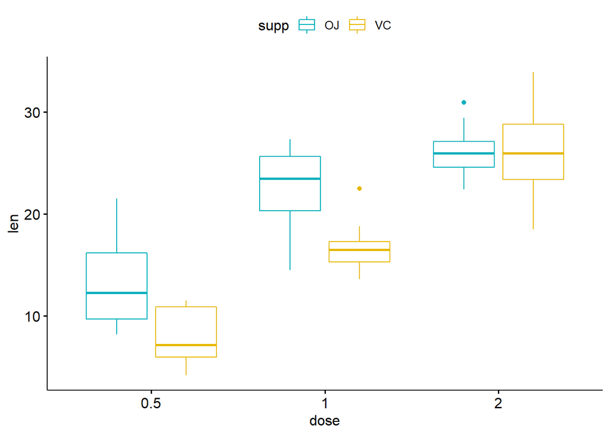

```r
library(ggpubr)
ggboxplot(data, x = "dose", y = "len", color = "supp",
palette = c("#00AFBB", "#E7B800"))
```

El test lo podemos realizar, como se indica a continuación, añadiendo las dos variables de interés a la parte derecha de la ecuación.

```r
model <- aov(len ~ dose + supp, data = data)
summary(model)
```

```
##             Df Sum Sq Mean Sq F value   Pr(>F)
## dose         1 2224.3  2224.3  123.99 6.31e-16 ***
## supp         1  205.3   205.3   11.45   0.0013 **
## Residuals   57 1022.6    17.9
## ---
## Signif. codes:  0 '***' 0.001 '**' 0.01 '*' 0.05 '.' 0.1 ' ' 1
```

Tal y como muestra el resumen del test, ambas variables tienen un efecto significativo de manera independiente en la longitud de los dientes. Podemos estudiar también las consecuencias de la interacción entre ambos factores. Esto se puede incluir en el modelo *multiplicando* ambos factores, como se ve a continuación.

```r
model <- aov(len ~ dose + supp + dose*supp, data = data)
summary(model)
```

```
##             Df Sum Sq Mean Sq F value   Pr(>F)
## dose         1 2224.3  2224.3 133.415  < 2e-16 ***
## supp         1  205.3   205.3  12.317 0.000894 ***
## dose:supp    1   88.9    88.9   5.333 0.024631 *
## Residuals   56  933.6    16.7
## ---
## Signif. codes:  0 '***' 0.001 '**' 0.01 '*' 0.05 '.' 0.1 ' ' 1
```

En esta ocasión, se puede apreciar que la interacción de ambos factores también es significativa. Es decir, la combinación del tipo de dosis y de la manera de administración genera un efecto estadísticamente significativo en la longitud de los dientes de los conejillos de indias.

El tamaño de efecto se puede comprobar con la función `eta_squared` del paquete `rstatix`. La podemos llamar poniendo `rstatix::` delante.

```r
rstatix::eta_squared(lm(len ~ dose + supp + dose*supp, data = data))
```

```
##       dose       supp  dose:supp
## 0.64431327 0.05948365 0.02575745
```

Como se puede ver, el tamaño de efecto asociado a la dosis es grande, y el del suplemento es mediano, mientras que el de la interacción de ambos factores es pequeño. Por lo tanto, los tres factores tienen una influencia significativa en la longitud de los dientes, siendo la dosis la que tiene un mayor efecto. Por otro lado, el tipo de suplemento afecta en menor medida, teniendo un tamaño de efecto mediano, y la interacción de ambos factores presenta un efecto pequeño.

## Visualización de contraste de medias

Las visualizaciones que hemos visto hasta ahora pueden completarse mostrando los resultados de los test, incluyendo, por ejemplo, sus p-valores. A tal efecto utilizaremos las librerías `rstatix`, que ofrecen una gran variedad de test estadísticos en un formato más interoperable, y `ggpubr`, que se encargará de la parte gráfica. Primero se realiza el test, y luego se añade a la visualización con la función `stat_pvalue_manual`. Al test se le añade la función `add_xy_position` para ubicar los corchetes gráficamente.

- Se puede añadir el p-valor del test

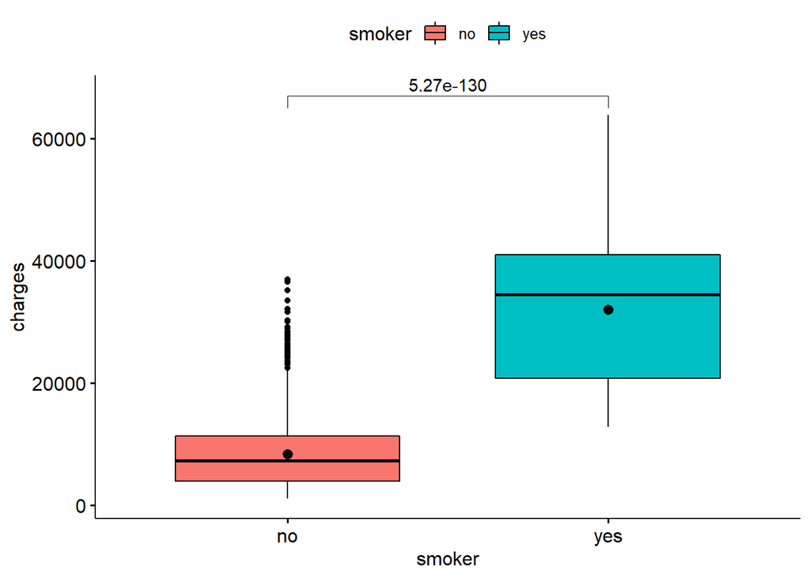

```r
library(rstatix)
library(ggpubr)

test <- wilcox_test(data = insurance, formula = charges ~ smoker)

ggboxplot(insurance, y= "charges", x = "smoker", fill = "smoker", add = "mean")+
  stat_pvalue_manual(test%>%add_xy_position(), label = "p")
```

- Se puede añadir el nivel de significatividad

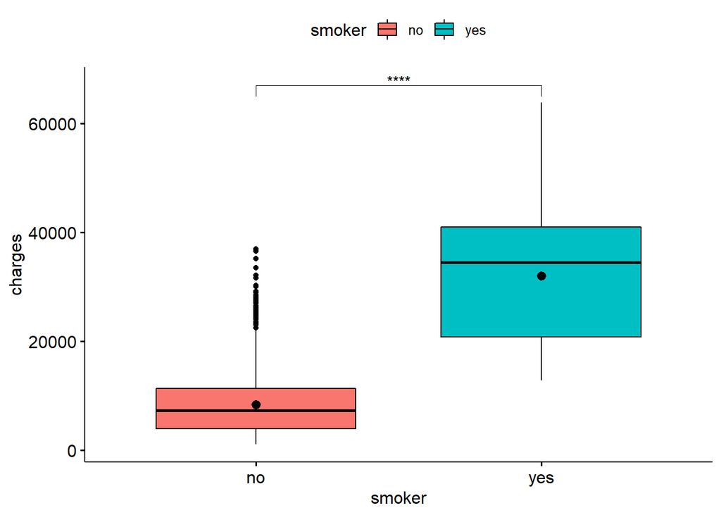

```r
test <- test%>%add_significance()
ggboxplot(insurance, y= "charges", x = "smoker", fill = "smoker", add = "mean")+
  stat_pvalue_manual(test%>%add_xy_position(), label = "p.signif")
```

- Además, se pueden añadir más elementos, como la media como texto

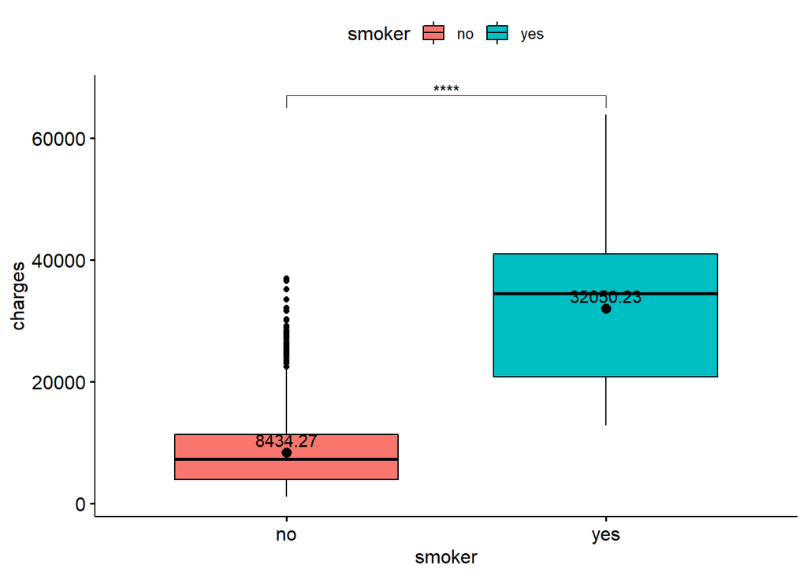

```r
means <- aggregate(charges~smoker, insurance, mean) #Se calcula la media del coste por categoría de fumador
means$charges <- round(means$charges,2) #Redondeamos el valor, por motivos gráficos

ggboxplot(insurance, y= "charges", x = "smoker", fill = "smoker", add = "mean")+
          stat_pvalue_manual(test%>%add_xy_position(), label = "p.signif")+
          geom_text(data = means, aes(label = charges, y = charges + 2000)) #Añadimos un desvio de 2000 unidades para que el texto con la media no se superponga al punto que marca la media
```

## Contraste para varianzas: análisis de la homocedasticidad

### Test de Levene

Para comprobar la homocedasticidad de una variable en relación con otra podemos utilizar el test de Levene, del paquete `rstatix`. Para ello se aplica una fórmula, en la que se escribe a la izquierda la variable de la que queremos comprobar la homocedasticidad y a la derecha la variable dependiente. Por ejemplo, para estudiar la homocedasticidad de la variable edad entre los dos sexos, haremos:

```r
rstatix::levene_test(formula = age~sex, data = insurance)
```

| df1 | df2 | statistic | p |
| --- | --- | --- | --- |
| 1 | 1336 | 0.0009092 | 0.9759491 |

El p-valor del test nos indica que no se puede descartar la hipótesis nula de homocedasticidad de la variable edad, por lo que asumimos que la varianza de la edad es estadísticamente igual en ambos grupos. Sin embargo, la varianza del coste de la póliza no es homocedástica al considerar ambos grupos, como se puede ver a continuación.

```r
rstatix::levene_test(formula = charges~sex, data = insurance)
```

| df1 | df2 | statistic | p |
| --- | --- | --- | --- |
| 1 | 1336 | 9.909251 | 0.0016809 |

## Bondad de ajuste: análisis de la normalidad

Los siguientes tests permiten comprar la normalidad de la distribución de los datos, es decir, si se deben utilizar tests paramétricos o no paramétricos para realizar contrastes de hipótesis.

### Test Kolmogorov-Smirnov

El test de Kolmogorov-Smirnov es una prueba estadística que nos indicará de manera numérica si una variable sigue una distribución normal o no lo hace. A priori, es apropiado utilizarla para variables continuas con un tamaño de muestra mayor de 50. El test se basa en un contraste de hipótesis, teniendo como hipótesis nula que no existe diferencia entre la distribución de nuestros datos y una distribución normal.

```r
set.seed(13)
 datosNormales <- rnorm(100)
 ks.test(datosNormales, "pnorm")
```

```
##
##  Asymptotic one-sample Kolmogorov-Smirnov test
##
## data:  datosNormales
## D = 0.062087, p-value = 0.8355
## alternative hypothesis: two-sided
```

En este caso hemos utilizado el test Kolmogorov-Smirnov para comprobar si una distribución generada a partir de `rnorm` era normal. El p-valor obtenido es de 0.8, por lo que podemos aceptar que sí lo es.

Por otro lado, si hicieramos el test a la variable `age`, que el *Q-Q plot* ya dejaba ver su no normalidad, obtendríamos un p-valor de $2.2e-16$, prácticamente 0, indicando que, efectivamente, es una variable no distribuida normalmente.

```r
edad <- insurance$age
ks.test(edad, "pnorm")
```

```
##
##  Asymptotic one-sample Kolmogorov-Smirnov test
##
## data:  edad
## D = 1, p-value < 2.2e-16
## alternative hypothesis: two-sided
```

- **Test de Kolmogorov-Smirnov con modificación de Lilliefors**

El test de Kolmogorov-Smirnov ha sido bastante criticado debido a que asume que se conoce la media y la desviación poblacional, lo que en la mayoría de los casos no es posible. Esto hace que el test sea conservador y poco potente, es decir, pocas veces concluye que la distribución no es normal. Para solventar este problema, existe una variante del test llamada “la corrección de Lilliefors” o “Test Lilliefors”, que no parte de la base de que conocemos la media y la desviación. En R el test Lilliefors no se encuentra en el paquete básico precargado, por lo que será necesario instalar el paquete estadístico `DescTools`.

```r
library(DescTools)
datosNormales <- rnorm(100)
LillieTest(datosNormales)
```

```
##
##  Lilliefors (Kolmogorov-Smirnov) normality test
##
## data:  datosNormales
## D = 0.055891, p-value = 0.6195
```

Observamos que el p-valor sigue estando por encima de 0.05, indicando que la distribución es normal. Sin embargo, es menor que el obtenido con el de Kolmogorov-Smirnov, ya que es un test más exigente que este.

### Test Shapiro-Wilk

Cuando contamos con un número de muestras pequeño, menor de 50 valores, tanto el test de Kolmogorov-Smirnov como su corrección de Lilliefors no son apropiados, y se necesita uno más sensible. En estos casos, se utiliza el test Shapiro-Wilk, que continúa teniendo como hipótesis nula que los datos tienen una distribución normal.

```r
datosNormales <- rnorm(30)
shapiro.test(datosNormales)
```

```
##
##  Shapiro-Wilk normality test
##
## data:  datosNormales
## W = 0.96933, p-value = 0.521
```

## Categorizando variables cuantitativas

Durante este capítulo hemos presentado numerosos test estadísticos donde la variable independiente es una variable categórica. Sin embargo, es posible aplicarlos también sobre cuantitativas transformando estas variables en categóricas.

Primero, utilizaremos una serie de condiciones anidadas gracias a la función `ifelse`, a la cual se le pasa como argumento la condición que queremos investigar, y después qué tiene que devolver si se cumple y si no se cumple. Vamos a dividir la edad en tres rangos que a priori pueden tener sentido.

```r
edad <- insurance$age
insurance$edadDiscret <- ifelse(edad<=30, "joven",
                                ifelse(edad>=61, "mayor",
                                        "edad media"))
table(insurance$edadDiscret)
```

```
##
## edad media      joven      mayor
##        803        444         91
```

A continuación, usaremos la función `discretize` de `arules` para conseguir 3 cortes (`breaks`) equiespaciados, utilizando el método `interval`. En este caso, los tramos que sugiere la función se hacen teniendo en cuenta la muestra disponible.

```r
library(arules)
insurance$edadDiscret <- discretize(edad, method = "interval", breaks = 3)
table(insurance$edadDiscret)
```

```
##
##   [18,33.3) [33.3,48.7)   [48.7,64]
##         523         402         413
```

Finalmente, vamos a hacer de nuevo 3 grupos (`breaks`) de manera que todos tengan el mismo número aproximado de individuos en ellos, utilizando el método `frequency`. En esta ocasión, los tramos de edad que sugiere la función son similares a los obtenidos para intervalos equiespaciados. Sin embargo, la cantidad de individuos por grupo está mejor distribuida.

```r
library(arules)
insurance$edadDiscret <- discretize(edad, method = "frequency", breaks = 3)
table(insurance$edadDiscret)
```

```
##
## [18,31) [31,47) [47,64]
##     444     423     471
```